# Data Analysis: Investigating Effects of Environmental Landmarks on Spatial Memory of Virtual Objects in Augmented Reality

Last update: Anonymous

06 September, 2023

# 1 Accuracy Results

We measured Accuracy and Euclidean Error from the experiment. The following R codes will illustrate the details of our quantitative analysis.

## 1.1 R Libraries

```r
library(ggplot2)
library(pwr)
library(Rmisc)
library(ARTool)
library(stats)
library(dplyr)
library(effectsize)
```

## 1.2 Load raw Accuracy data into global environment

```r
load("data.accuracy.raw.Rdata")
str(data.accuracy.raw)
```

```
'data.frame':   320 obs. of  7 variables:
 $ PID           : Factor w/ 16 levels "1","2","3","4",..: 16 16 16 16 16 16 16 16 16 16 ...
 $ Condition     : Factor w/ 4 levels "Furniture-Irregular",..: 3 3 3 3 3 1 1 1 1 1 ...
 $ Furniture     : Factor w/ 2 levels "Furniture","NoFurniture": 2 2 2 2 2 1 1 1 1 1 ...
 $ Layout        : Factor w/ 2 levels "Irregular","Regular": 1 1 1 1 1 1 1 1 1 1 ...
 $ Accuracy      : num  1 1 1 0.8 0.8 1 1 1 1 1 ...
 $ EuclideanError: num  0 0 0 0.6 0.765 ...
 $ LearningTime  : num  16.9 18.5 15 15 15 ...
```

```r
summary(data.accuracy.raw)
```

```
      PID                      Condition        Furniture         Layout       Accuracy      EuclideanError   LearningTime
 1      : 20   Furniture-Irregular  :80   Furniture  :160   Irregular:160   Min.   :0.0000   Min.   :0.000   Min.   :15.00
 2      : 20   Furniture-Regular    :80   NoFurniture:160   Regular  :160   1st Qu.:0.2000   1st Qu.:0.600   1st Qu.:15.06
 3      : 20   NoFurniture-Irregular:80                                     Median :0.4000   Median :2.000   Median :17.34
 4      : 20   NoFurniture-Regular  :80                                     Mean   :0.5269   Mean   :2.167   Mean   :20.87
 5      : 20                                                                3rd Qu.:0.8000   3rd Qu.:3.540   3rd Qu.:23.18
 6      : 20                                                                Max.   :1.0000   Max.   :7.092   Max.   :78.00
 (Other):200
```

By checking the raw data, we can see all 320 observations (16 participants * 2 Furniture conditions * 2 Layout conditions * 5 repetitions). We have one independent variable (condition), which can be further split into two independent variables (Furniture and Layout). We also have two dependent variables (Accuracy and Euclidean Error). At the end, we have tahe learning time recorded to see if any experiment trials are outliers.

## 1.3 Data Wrangling

### 1.3.1 Visualizing Outliers

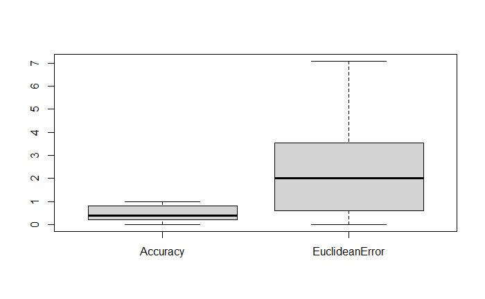

```r
boxplot(data.accuracy.raw[,5:6])
```

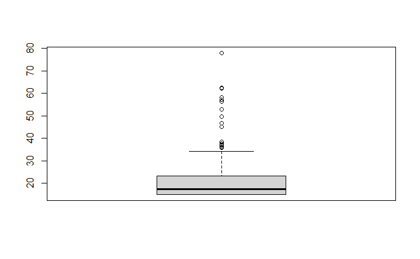

```r
boxplot(data.accuracy.raw$LearningTime)
```

From the boxplots, we can see that Accuracy and Euclidean Error data have no outlier, but the Learning Time data have outliers. We will need to exclude those outliers which imply that participant didn’t follow the experimental rule in those trials.

### 1.3.2 Finding Outliers based on Learning Time

```r
Q <- quantile(data.accuracy.raw$LearningTime, probs=c(.25, .75), na.rm = FALSE)
iqr <- IQR(data.accuracy.raw$LearningTime)
up <-  Q[2]+1.5*iqr # Upper Range
outliers <- subset(data.accuracy.raw, data.accuracy.raw$LearningTime >= up)
outliers
```

|  | PID | Condition | Furniture | Layout | Accuracy | EuclideanError | LearningTime |
| --- | --- | --- | --- | --- | --- | --- | --- |
| 25 | 15 | Furniture-Irregular | Furniture | Irregular | 0.0 | 4.3304396 | 57.02 |
| 26 | 15 | Furniture-Regular | Furniture | Regular | 0.2 | 4.2797624 | 52.88 |
| 27 | 15 | Furniture-Regular | Furniture | Regular | 0.0 | 4.9206467 | 36.68 |
| 29 | 15 | Furniture-Regular | Furniture | Regular | 0.4 | 3.5367102 | 37.18 |
| 41 | 14 | NoFurniture-Regular | NoFurniture | Regular | 0.0 | 3.6951677 | 45.04 |
| 57 | 14 | Furniture-Irregular | Furniture | Irregular | 0.4 | 3.2609435 | 46.82 |
| 61 | 13 | Furniture-Regular | Furniture | Regular | 0.2 | 5.1159270 | 38.50 |
| 92 | 12 | NoFurniture-Regular | NoFurniture | Regular | 0.4 | 1.9000007 | 62.12 |
| 97 | 12 | Furniture-Regular | Furniture | Regular | 0.4 | 1.5999996 | 78.00 |
| 101 | 11 | Furniture-Irregular | Furniture | Irregular | 0.4 | 2.4748327 | 58.30 |

[output cut: 9 more lines]

We found 19 trials where participants spent more than expected time (> 35.3s) during the learning phase, causing the data not valid. We then remove those 19 trials from the raw data.

### 1.3.3 Eliminating Outliers

```r
data.accuracy.eliminated <- subset(data.accuracy.raw, data.accuracy.raw$LearningTime < up)
str(data.accuracy.eliminated)
```

```
'data.frame':   301 obs. of  7 variables:
 $ PID           : Factor w/ 16 levels "1","2","3","4",..: 16 16 16 16 16 16 16 16 16 16 ...
 $ Condition     : Factor w/ 4 levels "Furniture-Irregular",..: 3 3 3 3 3 1 1 1 1 1 ...
 $ Furniture     : Factor w/ 2 levels "Furniture","NoFurniture": 2 2 2 2 2 1 1 1 1 1 ...
 $ Layout        : Factor w/ 2 levels "Irregular","Regular": 1 1 1 1 1 1 1 1 1 1 ...
 $ Accuracy      : num  1 1 1 0.8 0.8 1 1 1 1 1 ...
 $ EuclideanError: num  0 0 0 0.6 0.765 ...
 $ LearningTime  : num  16.9 18.5 15 15 15 ...
```

```r
summary(data.accuracy.eliminated)
```

```
      PID                      Condition        Furniture         Layout       Accuracy      EuclideanError   LearningTime
 1      : 20   Furniture-Irregular  :76   Furniture  :148   Irregular:154   Min.   :0.0000   Min.   :0.000   Min.   :15.00
 3      : 20   Furniture-Regular    :72   NoFurniture:153   Regular  :147   1st Qu.:0.2000   1st Qu.:0.600   1st Qu.:15.06
 4      : 20   NoFurniture-Irregular:78                                     Median :0.6000   Median :2.000   Median :16.94
 8      : 20   NoFurniture-Regular  :75                                     Mean   :0.5322   Mean   :2.154   Mean   :19.20
 10     : 20                                                                3rd Qu.:0.8000   3rd Qu.:3.536   3rd Qu.:21.90
 16     : 20                                                                Max.   :1.0000   Max.   :7.092   Max.   :34.22
 (Other):181
```

After removing, we have 301 observations left for further analysis.

### 1.3.4 Aggregate Accuracy Data

```r
summary(data.accuracy)
```

```
      PID                     Condition        Furniture        Layout      Accuracy      EuclideanError
 1      : 4   Furniture-Irregular  :16   Furniture  :32   Irregular:32   Min.   :0.1500   Min.   :0.000
 2      : 4   Furniture-Regular    :16   NoFurniture:32   Regular  :32   1st Qu.:0.3200   1st Qu.:1.225
 3      : 4   NoFurniture-Irregular:16                                   Median :0.4800   Median :2.393
 4      : 4   NoFurniture-Regular  :16                                   Mean   :0.5361   Mean   :2.137
 5      : 4                                                              3rd Qu.:0.7200   3rd Qu.:3.069
 6      : 4                                                              Max.   :1.0000   Max.   :4.848
 (Other):40
```

Now, we have the aggregated dataset which contains the mean accuracy and euclidean error for each participant on each condition. Next, we will do some statistical analysis on this dataset.

### 1.3.5 Test normality in the main dataset

```r
shapiro.test(data.accuracy$Accuracy)
```

```
    Shapiro-Wilk normality test

data:  data.accuracy$Accuracy
W = 0.93801, p-value = 0.00307
```

```r
shapiro.test(data.accuracy$EuclideanError)
```

```
    Shapiro-Wilk normality test

data:  data.accuracy$EuclideanError
W = 0.95174, p-value = 0.01395
```

We can clearly see from the result that p values are all < 0.05, which means that the data of two dependent variables are not normally distributed. So we use ARTools to transform the data for different measurements. Below, we have separate sections for each accuracy measurements: Accuracy and Euclidean Error.

## 1.4 Normal Accuracy Analysis

The Normal Accuracy is calculated by the number of correct cards / 5. The correct card is measured if the user selected card matches the exact pattern card.

### 1.4.1 Data Transformation using ARTools model

```r
art.accuracy <- art(Accuracy ~ Furniture * Layout + Error(PID), data = data.accuracy)
art.accuracy.condition <- art(Accuracy ~ Condition + Error(PID), data = data.accuracy)
art.accuracy.furniture <- art(Accuracy ~ Furniture + Error(PID), data = data.accuracy)
art.accuracy.layout <- art(Accuracy ~ Layout + Error(PID), data = data.accuracy)
```

Now, we have four sub-models transformed by ARTools from the original data set for normal accuracy.

### 1.4.2 Analysis of Two Factors combination

#### 1.4.2.1 Check Homogenity

```r
bartlett.test(Accuracy ~ interaction(Furniture, Layout), data = data.accuracy)
```

```
    Bartlett test of homogeneity of variances

data:  Accuracy by interaction(Furniture, Layout)
Bartlett's K-squared = 1.0745, df = 3, p-value = 0.7832
```

From the output, it can be seen that the p-value of **0.7832** is not less than the significance level of 0.05. This means that there is no evidence to suggest that the variance in **Accuracy** is statistically significantly different among different **factors or the combination of factors**. Thus, we can assume the homogenity.

#### 1.4.2.2 Two-way Repeated measures ANOVA

```r
model.accuracy <- anova(art.accuracy)
model.accuracy$part.eta.sq = with(model.accuracy, `Sum Sq`/(`Sum Sq` + `Sum Sq.res`))

model.accuracy
```

```
Analysis of Variance of Aligned Rank Transformed Data

Table Type: Repeated Measures Analysis of Variance Table (Type I)
Model: Repeated Measures (aov)
Response: art(Accuracy)

                   Error Df Df.res F value   Pr(>F) part.eta.sq
1 Furniture        Withn  1     45 4.46975 0.040074    0.090353 *
2 Layout           Withn  1     45 2.40613 0.127866    0.050756
3 Furniture:Layout Withn  1     45 0.15031 0.700070    0.003329
---
Signif. codes:   0 ‘***’ 0.001 ‘**’ 0.01 ‘*’ 0.05 ‘.’ 0.1 ‘ ’ 1
```

From the two-way repeated measures ANOVA results above, we can see that only furniture has the significant main effect (p < 0.05). The effect size 0.09 is calculated using partial eta-squared, which implies a medium effect (0.06-0.14).

### 1.4.3 Analysis of Furniture Factor

#### 1.4.3.1 Check Homogenity

```r
bartlett.test(Accuracy ~ Furniture, data = data.accuracy)
```

```
    Bartlett test of homogeneity of variances

data:  Accuracy by Furniture
Bartlett's K-squared = 0.7984, df = 1, p-value = 0.3716
```

From the output, it can be seen that the p-value of **0.3716** is not less than the significance level of 0.05. This means that there is no evidence to suggest that the variance in **Accuracy** is statistically significantly different among different **Furniture conditions**. Thus, we can assume the homogenity.

#### 1.4.3.2 One-way Repeated measures ANOVA

```r
model.accuracy.furniture <- anova(art.accuracy.furniture)
model.accuracy.furniture$part.eta.sq = with(model.accuracy.furniture, `Sum Sq`/(`Sum Sq` + `Sum Sq.res`))

model.accuracy.furniture
```

```
Analysis of Variance of Aligned Rank Transformed Data

Table Type: Repeated Measures Analysis of Variance Table (Type I)
Model: Repeated Measures (aov)
Response: art(Accuracy)

            Error Df Df.res F value   Pr(>F) part.eta.sq
1 Furniture Withn  1     47  4.7097 0.035079     0.09108 *
---
Signif. codes:   0 ‘***’ 0.001 ‘**’ 0.01 ‘*’ 0.05 ‘.’ 0.1 ‘ ’ 1
```

From the one-way repeated measures ANOVA results above, we can see that **furniture has the significant main effect (p < 0.05)**. The **effect size 0.09** is calculated using partial eta-squared, which implies a **medium effect (0.06-0.14)**.

#### 1.4.3.3 Power Analysis

```r
k=2
n=32
f=eta2_to_f(0.09108)
sig.level = 0.05
pwr.anova.test(k, n, f, sig.level)
```

```
     Balanced one-way analysis of variance power calculation

              k = 2
              n = 32
              f = 0.3165546
      sig.level = 0.05
          power = 0.7030161

NOTE: n is number in each group
```

A Post-hoc power calculations for balanced ANOVA test was conducted to determine the power of our tested study hypothesis, which compared Furniture to No Furniture conditions. The effect size of the study is 0.09 (partial eta-squared)/0.32 (Cohen’s f) with 32 observations in two groups. The calculated power is 0.7.

#### 1.4.3.4 Visualisation

```r
d <- Rmisc::summarySE(data.accuracy, measurevar = "Accuracy", groupvars = c("Furniture"))
d
```

| Furniture | N | Accuracy | sd | se | ci |
| --- | --- | --- | --- | --- | --- |
| Furniture | 32 | 0.5734375 | 0.2679505 | 0.04736741 | 0.09660646 |
| NoFurniture | 32 | 0.4987500 | 0.2278476 | 0.04027814 | 0.08214781 |

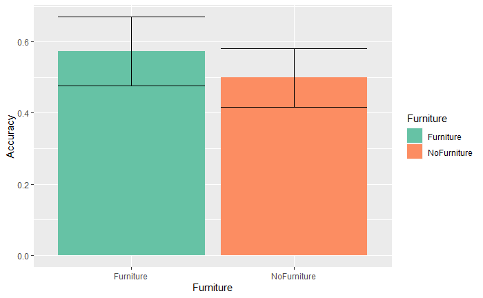

```r
ggplot(d, aes(x = Furniture, y = Accuracy, fill = Furniture)) + geom_bar(stat = "identity") + geom_errorbar(aes(ymin=Accuracy-ci, ymax=Accuracy+ci)) + scale_fill_manual(values=c("#66c2a5", "#fc8d62"))
```

### 1.4.4 Analysis of Layout Factor

#### 1.4.4.1 Check Homogenity

```r
bartlett.test(Accuracy ~ Layout, data = data.accuracy)
```

```
    Bartlett test of homogeneity of variances

data:  Accuracy by Layout
Bartlett's K-squared = 0.066248, df = 1, p-value = 0.7969
```

From the output, it can be seen that the p-value of **0.7969** is not less than the significance level of 0.05. This means that there is no evidence to suggest that the variance in **Accuracy** is statistically significantly different among different **Layout conditions**. Thus, we can assume the homogenity.

#### 1.4.4.2 One-way Repeated measures ANOVA

```r
model.accuracy.layout<- anova(art.accuracy.layout)
model.accuracy.layout$part.eta.sq = with(model.accuracy.layout, `Sum Sq`/(`Sum Sq` + `Sum Sq.res`))

model.accuracy.layout
```

```
Analysis of Variance of Aligned Rank Transformed Data

Table Type: Repeated Measures Analysis of Variance Table (Type I)
Model: Repeated Measures (aov)
Response: art(Accuracy)

         Error Df Df.res F value  Pr(>F) part.eta.sq
1 Layout Withn  1     47  2.0974 0.15419    0.042718
---
Signif. codes:   0 ‘***’ 0.001 ‘**’ 0.01 ‘*’ 0.05 ‘.’ 0.1 ‘ ’ 1
```

From the one-way repeated measures ANOVA results above, we cannot find any significant main effect **for the layout factor (p = 0.15)**.

#### 1.4.4.3 Visualisation

```r
d <- Rmisc::summarySE(data.accuracy, measurevar = "Accuracy", groupvars = c("Layout"))
d
```

| Layout | N | Accuracy | sd | se | ci |
| --- | --- | --- | --- | --- | --- |
| Irregular | 32 | 0.5103125 | 0.2443224 | 0.04319051 | 0.08808763 |
| Regular | 32 | 0.5618750 | 0.2559793 | 0.04525118 | 0.09229038 |

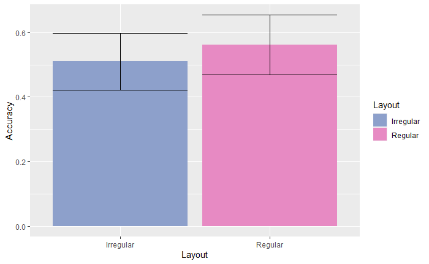

```r
ggplot(d, aes(x = Layout, y = Accuracy, fill = Layout)) + geom_bar(stat = "identity") + geom_errorbar(aes(ymin=Accuracy-ci, ymax=Accuracy+ci)) + scale_fill_manual(values=c("#8da0cb", "#e78ac3"))
```

### 1.4.5 Analysis of Four Conditions

#### 1.4.5.1 Check Homogenity

```r
bartlett.test(Accuracy ~ Condition, data = data.accuracy)
```

```
    Bartlett test of homogeneity of variances

data:  Accuracy by Condition
Bartlett's K-squared = 1.0745, df = 3, p-value = 0.7832
```

From the output, it can be seen that the p-value of **0.7832** is not less than the significance level of 0.05. This means that there is no evidence to suggest that the variance in **accuracy** is statistically significantly different among different **conditions**. Thus, we can assume the homogenity.

#### 1.4.5.2 One-way Repeated measures ANOVA

```r
model.accuracy.condition <- anova(art.accuracy.condition)
model.accuracy.condition$part.eta.sq = with(model.accuracy.condition, `Sum Sq`/(`Sum Sq` + `Sum Sq.res`))

model.accuracy.condition
```

```
Analysis of Variance of Aligned Rank Transformed Data

Table Type: Repeated Measures Analysis of Variance Table (Type I)
Model: Repeated Measures (aov)
Response: art(Accuracy)

            Error Df Df.res F value   Pr(>F) part.eta.sq
1 Condition Withn  3     45  2.3266 0.087353     0.13428 .
---
Signif. codes:   0 ‘***’ 0.001 ‘**’ 0.01 ‘*’ 0.05 ‘.’ 0.1 ‘ ’ 1
```

From the one-way repeated measures ANOVA results above, we cannot find a strong significant main effect **among the four conditions (p = 0.08)**.

#### 1.4.5.3 Visualisation

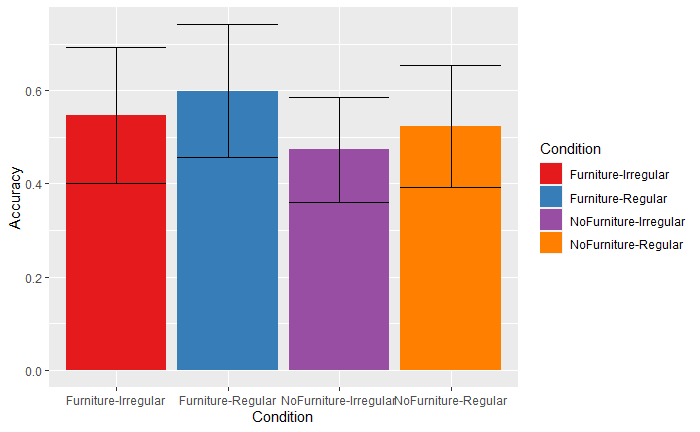

```r
d <- Rmisc::summarySE(data.accuracy, measurevar = "Accuracy", groupvars = c("Condition"))
ggplot(d, aes(x = Condition, y = Accuracy, fill = Condition)) + geom_bar(stat = "identity") + geom_errorbar(aes(ymin=Accuracy-ci, ymax=Accuracy+ci)) + scale_fill_manual(values=c("#e41a1c", "#377eb8", "#984ea3", "#ff7f00"))
```

## 1.5 Euclidean Distance Analysis

The Euclidean Distance provides a secondary evaluation of the error measure. Whereas Cards Incorrect provides an absolute measure, Euclidean Distance rewards card selections by summing the distance from the selected cards to the correct ones via the Hungarian Algorithm.

### 1.5.1 Data Transformation using ARTools model

```r
art.ee <- art(EuclideanError ~ Furniture * Layout + Error(PID), data = data.accuracy)
art.ee.furniture <- art(EuclideanError ~ Furniture + Error(PID), data = data.accuracy)
art.ee.layout <- art(EuclideanError ~ Layout + Error(PID), data = data.accuracy)
art.ee.condition <- art(EuclideanError ~ Condition + Error(PID), data = data.accuracy)
```

Now, we have four sub-models transformed by ARTools from the original data set for Euclidean Distance.

### 1.5.2 Analysis of Two Factors combination

#### 1.5.2.1 Check Homogenity

```r
bartlett.test(EuclideanError ~ interaction(Furniture, Layout), data = data.accuracy)
```

```
    Bartlett test of homogeneity of variances

data:  EuclideanError by interaction(Furniture, Layout)
Bartlett's K-squared = 3.7551, df = 3, p-value = 0.2891
```

From the output, it can be seen that the p-value of **0.2891** is not less than the significance level of 0.05. This means that there is no evidence to suggest that the variance in **Euclidean Distance** is statistically significantly different among different **factors or the combination of factors**. Thus, we can assume the homogenity.

#### 1.5.2.2 Two-way Repeated measures ANOVA

```r
model.ee <- anova(art.ee)
model.ee$part.eta.sq = with(model.ee, `Sum Sq`/(`Sum Sq` + `Sum Sq.res`))

model.ee
```

```
Analysis of Variance of Aligned Rank Transformed Data

Table Type: Repeated Measures Analysis of Variance Table (Type I)
Model: Repeated Measures (aov)
Response: art(EuclideanError)

                   Error Df Df.res    F value  Pr(>F) part.eta.sq
1 Furniture        Withn  1     45 1.99248680 0.16496  4.2400e-02
2 Layout           Withn  1     45 0.00031774 0.98586  7.0609e-06
3 Furniture:Layout Withn  1     45 0.15327234 0.69728  3.3945e-03
---
Signif. codes:   0 ‘***’ 0.001 ‘**’ 0.01 ‘*’ 0.05 ‘.’ 0.1 ‘ ’ 1
```

From the two-way repeated measures ANOVA results above, we cannot find any evidence to suggest a significant difference for any factors or combinations of factors.

### 1.5.3 Analysis of Furniture Factor

#### 1.5.3.1 Check Homogenity

```r
bartlett.test(EuclideanError ~ Furniture, data = data.accuracy)
```

```
    Bartlett test of homogeneity of variances

data:  EuclideanError by Furniture
Bartlett's K-squared = 2.8296, df = 1, p-value = 0.09254
```

From the output, it can be seen that the p-value of **0.09254** is not less than the significance level of 0.05. This means that there is no evidence to suggest that the variance in **Euclidean Distance** is statistically significantly different among different **Furniture conditions**. Thus, we can assume the homogenity.

#### 1.5.3.2 One-way Repeated measures ANOVA

```r
model.ee.furniture <- anova(art.ee.furniture)
model.ee.furniture$part.eta.sq = with(model.ee.furniture, `Sum Sq`/(`Sum Sq` + `Sum Sq.res`))

model.ee.furniture
```

```
Analysis of Variance of Aligned Rank Transformed Data

Table Type: Repeated Measures Analysis of Variance Table (Type I)
Model: Repeated Measures (aov)
Response: art(EuclideanError)

            Error Df Df.res F value  Pr(>F) part.eta.sq
1 Furniture Withn  1     47   1.965 0.16755     0.04013
---
Signif. codes:   0 ‘***’ 0.001 ‘**’ 0.01 ‘*’ 0.05 ‘.’ 0.1 ‘ ’ 1
```

From the one-way repeated measures ANOVA results above, we cannot find any significant main effect **for the Furniture factor (p = 0.17)**.

#### 1.5.3.3 Visualisation

```r
d <- Rmisc::summarySE(data.accuracy, measurevar = "EuclideanError", groupvars = c("Furniture"))
d
```

| Furniture | N | EuclideanError | sd | se | ci |
| --- | --- | --- | --- | --- | --- |
| Furniture | 32 | 1.988949 | 1.426198 | 0.2521186 | 0.5141992 |
| NoFurniture | 32 | 2.285920 | 1.049282 | 0.1854886 | 0.3783065 |

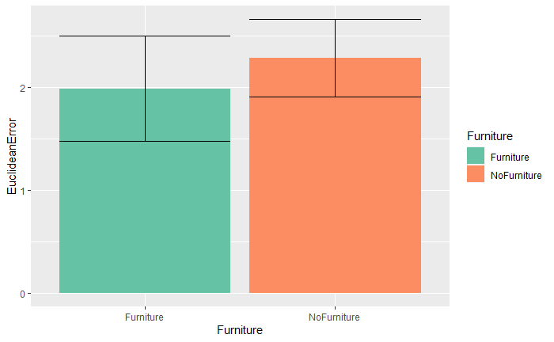

```r
ggplot(d, aes(x = Furniture, y = EuclideanError, fill = Furniture)) + geom_bar(stat = "identity") + geom_errorbar(aes(ymin=EuclideanError-ci, ymax=EuclideanError+ci)) + scale_fill_manual(values=c("#66c2a5", "#fc8d62"))
```

### 1.5.4 Analysis of Layout Factor

#### 1.5.4.1 Check Homogenity

```r
bartlett.test(EuclideanError ~ Layout, data = data.accuracy)
```

```
    Bartlett test of homogeneity of variances

data:  EuclideanError by Layout
Bartlett's K-squared = 0.43863, df = 1, p-value = 0.5078
```

From the output, it can be seen that the p-value of **0.5078** is not less than the significance level of 0.05. This means that there is no evidence to suggest that the variance in **Euclidean Distance** is statistically significantly different among different **Layout conditions**. Thus, we can assume the homogenity.

#### 1.5.4.2 One-way Repeated measures ANOVA

```r
model.ee.layout<- anova(art.ee.layout)
model.ee.layout$part.eta.sq = with(model.ee.layout, `Sum Sq`/(`Sum Sq` + `Sum Sq.res`))

model.ee.layout
```

```
Analysis of Variance of Aligned Rank Transformed Data

Table Type: Repeated Measures Analysis of Variance Table (Type I)
Model: Repeated Measures (aov)
Response: art(EuclideanError)

         Error Df Df.res   F value  Pr(>F) part.eta.sq
1 Layout Withn  1     47 0.0050904 0.94342   0.0001083
---
Signif. codes:   0 ‘***’ 0.001 ‘**’ 0.01 ‘*’ 0.05 ‘.’ 0.1 ‘ ’ 1
```

From the one-way repeated measures ANOVA results above, we cannot find any significant main effect **for the layout factor (p = 0.94)**.

#### 1.5.4.3 Visualisation

```r
d <- Rmisc::summarySE(data.accuracy, measurevar = "EuclideanError", groupvars = c("Layout"))
d
```

| Layout | N | EuclideanError | sd | se | ci |
| --- | --- | --- | --- | --- | --- |
| Irregular | 32 | 2.172735 | 1.182854 | 0.2091010 | 0.4264643 |
| Regular | 32 | 2.102134 | 1.333730 | 0.2357724 | 0.4808610 |

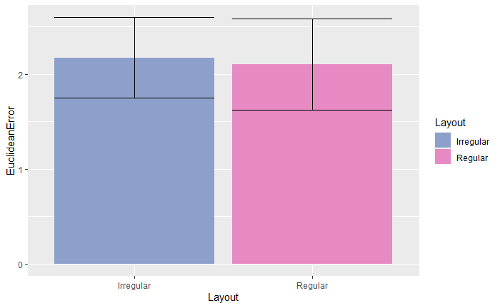

```r
ggplot(d, aes(x = Layout, y = EuclideanError, fill = Layout)) + geom_bar(stat = "identity") + geom_errorbar(aes(ymin=EuclideanError-ci, ymax=EuclideanError+ci)) + scale_fill_manual(values=c("#8da0cb", "#e78ac3"))
```

### 1.5.5 Analysis of Four Conditions

#### 1.5.5.1 Check Homogenity

```r
bartlett.test(EuclideanError ~ Condition, data = data.accuracy)
```

```
    Bartlett test of homogeneity of variances

data:  EuclideanError by Condition
Bartlett's K-squared = 3.7551, df = 3, p-value = 0.2891
```

From the output, it can be seen that the p-value of **0.2891** is not less than the significance level of 0.05. This means that there is no evidence to suggest that the variance in **Euclidean Distance** is statistically significantly different among different **conditions**. Thus, we can assume the homogenity.

#### 1.5.5.2 One-way Repeated measures ANOVA

```r
model.ee.condition <- anova(art.ee.condition)
model.ee.condition$part.eta.sq = with(model.ee.condition, `Sum Sq`/(`Sum Sq` + `Sum Sq.res`))

model.ee.condition
```

```
Analysis of Variance of Aligned Rank Transformed Data

Table Type: Repeated Measures Analysis of Variance Table (Type I)
Model: Repeated Measures (aov)
Response: art(EuclideanError)

            Error Df Df.res F value  Pr(>F) part.eta.sq
1 Condition Withn  3     45  0.6608 0.58049    0.042195
---
Signif. codes:   0 ‘***’ 0.001 ‘**’ 0.01 ‘*’ 0.05 ‘.’ 0.1 ‘ ’ 1
```

From the one-way repeated measures ANOVA results above, we cannot find a strong significant main effect **among the four conditions (p = 0.58)**.

#### 1.5.5.3 Visualisation

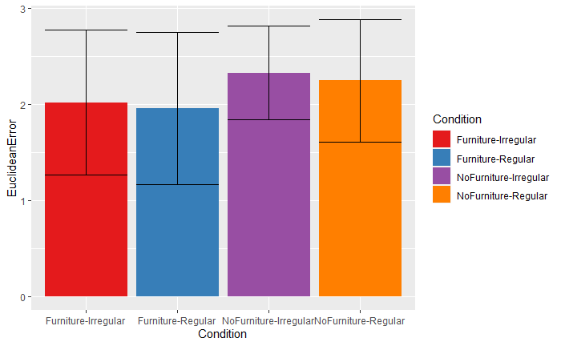

```r
d <- Rmisc::summarySE(data.accuracy, measurevar = "EuclideanError", groupvars = c("Condition"))
ggplot(d, aes(x = Condition, y = EuclideanError, fill = Condition)) + geom_bar(stat = "identity") + geom_errorbar(aes(ymin=EuclideanError-ci, ymax=EuclideanError+ci)) + scale_fill_manual(values=c("#e41a1c", "#377eb8", "#984ea3", "#ff7f00"))
```

## 1.6 Gender Analysis

### 1.6.1 Testing Normality

```r
shapiro.test(data.accuracy.female$Accuracy)
```

```
    Shapiro-Wilk normality test

data:  data.accuracy.female$Accuracy
W = 0.94031, p-value = 0.07641
```

```r
shapiro.test(data.accuracy.male$Accuracy)
```

```
    Shapiro-Wilk normality test

data:  data.accuracy.male$Accuracy
W = 0.91875, p-value = 0.01923
```

```r
shapiro.test(data.accuracy.female$EuclideanError)
```

```
    Shapiro-Wilk normality test

data:  data.accuracy.female$EuclideanError
W = 0.93576, p-value = 0.05681
```

```r
shapiro.test(data.accuracy.male$EuclideanError)
```

```
    Shapiro-Wilk normality test

data:  data.accuracy.male$EuclideanError
W = 0.95309, p-value = 0.1763
```

Not all data are normally distributed, so we use non-parametric test.

### 1.6.2 Wilcoxon Signed-rank test

```r
wilcox.test(data.accuracy.female$Accuracy, data.accuracy.male$Accuracy, paired=T)
```

```
    Wilcoxon signed rank test with continuity correction

data:  data.accuracy.female$Accuracy and data.accuracy.male$Accuracy
V = 293.5, p-value = 0.5875
alternative hypothesis: true location shift is not equal to 0
```

```r
wilcox.test(data.accuracy.female$EuclideanError, data.accuracy.male$EuclideanError, paired=T)
```

```
    Wilcoxon signed rank exact test

data:  data.accuracy.female$EuclideanError and data.accuracy.male$EuclideanError
V = 236, p-value = 0.6117
alternative hypothesis: true location shift is not equal to 0
```

## 1.7 Conclusion for Normal Accuracy (Cards Incorrect)

The data for the normal accuracy are not normally distributed. So we use the Aligned Rank Transform (ART) to transform our non-parametric data and turn them into ANOVA models. The data meet the assumption of homogeneity of variances. The one-way repeated measures ANOVA test shows a significant effect of the Furniture factor (p=0.035, effect size eta-squared=0.09) with a higher accuracy for Furniture condition (mean=0.57, sd=0.27) vs No Furniture condition (mean=0.50, sd=0.23). We don’t find any evidence to suggest that the Layout factor has a main effect. Also, we don’t find any evidence to suggest that the four conditions are significantly different.

## 1.8 Conclusion for Euclidean Distance

The data for the Euclidean Distance are not normally distributed. So we use the Aligned Rank Transform (ART) to transform our non-parametric data and turn them into ANOVA models. The data meet the assumption of homogeneity of variances. Our results show that there is no evidence to suggest that Euclidean Distance measure is significant difference for any factor or combination of factors.

## 1.9 Conclusion and Visualisation for Gender Effect

```r
data.accuracy.female$Gender <- "Female"
data.accuracy.male$Gender <- "Male"
data.gender.combination <- rbind(data.accuracy.female, data.accuracy.male)

d1 <- Rmisc::summarySE(data.gender.combination, measurevar = "Accuracy", groupvars = c("Gender"))
d1
```

| Gender | N | Accuracy | sd | se | ci |
| --- | --- | --- | --- | --- | --- |
| Female | 32 | 0.5590625 | 0.2391701 | 0.04227969 | 0.08623000 |
| Male | 32 | 0.5131250 | 0.2613419 | 0.04619916 | 0.09422381 |

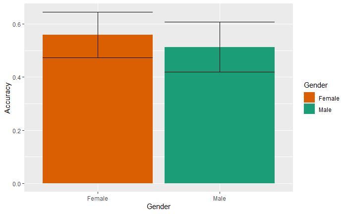

```r
ggplot(d1, aes(x = Gender, y = Accuracy, fill = Gender)) + geom_bar(stat = "identity") + geom_errorbar(aes(ymin=Accuracy-ci, ymax=Accuracy+ci)) + scale_fill_manual(values=c("#d95f02", "#1b9e77"))
```

```r
d2 <- Rmisc::summarySE(data.gender.combination, measurevar = "EuclideanError", groupvars = c("Gender"))
d2
```

| Gender | N | EuclideanError | sd | se | ci |
| --- | --- | --- | --- | --- | --- |
| Female | 32 | 2.041873 | 1.203951 | 0.2128305 | 0.4340707 |
| Male | 32 | 2.232997 | 1.308511 | 0.2313142 | 0.4717684 |

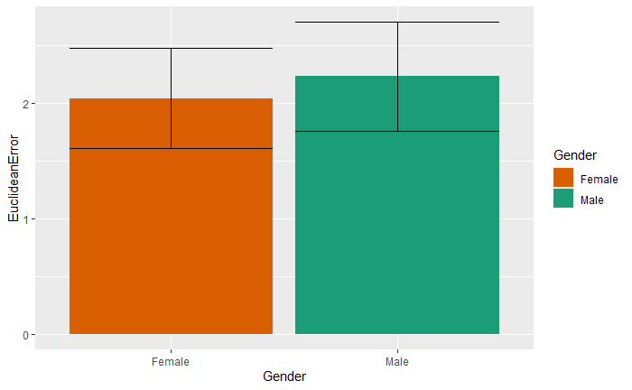

```r
ggplot(d2, aes(x = Gender, y = EuclideanError, fill = Gender)) + geom_bar(stat = "identity") + geom_errorbar(aes(ymin=EuclideanError-ci, ymax=EuclideanError+ci)) + scale_fill_manual(values=c("#d95f02", "#1b9e77"))
```

From the statistical analysis, we couldn’t find any evidence for a significant effect of different gender on accuracy data. Female participants have slightly higher accuracy (mean=0.56, sd=0.24) than male participants (mean=0.51, sd=0.26). Female participants also have slightly lower Euclidean Error (mean=2.04, sd=1.2) than male participants (mean=2.23, sd=1.31).

# 2 NASA-TLX Results

## 2.1 R Libraries

```r
library(tidyverse)
library(Rmisc)
library(ARTool)
library(stats)
library(dplyr)
library(rstatix)
library(coin)
```

## 2.2 Load cleaned subjective data into global environment

```r
load("data.subjective.Rdata")
summary(data.subjective)
```

```
  Timestamp              PID         Mental         Physical       Temporal      Performance        Effort       Frustration
 Length:64          1      : 4   Min.   :1.000   Min.   :1.00   Min.   :1.000   Min.   :2.000   Min.   :1.000   Min.   :1.000
 Class :character   2      : 4   1st Qu.:3.000   1st Qu.:3.00   1st Qu.:4.000   1st Qu.:4.000   1st Qu.:3.000   1st Qu.:2.000
 Mode  :character   3      : 4   Median :5.000   Median :5.00   Median :5.500   Median :5.000   Median :5.000   Median :3.500
                    4      : 4   Mean   :4.656   Mean   :4.25   Mean   :5.109   Mean   :4.656   Mean   :4.656   Mean   :3.516
                    5      : 4   3rd Qu.:6.000   3rd Qu.:5.25   3rd Qu.:6.000   3rd Qu.:6.000   3rd Qu.:6.000   3rd Qu.:5.000
                    6      : 4   Max.   :7.000   Max.   :7.00   Max.   :7.000   Max.   :7.000   Max.   :7.000   Max.   :7.000
                    (Other):40
      Mean                       Condition        Furniture        Layout
 Min.   :1.333   Furniture-Irregular  :16   Furniture  :32   Irregular:32
 1st Qu.:3.958   Furniture-Regular    :16   NoFurniture:32   Regular  :32
 Median :4.667   NoFurniture-Irregular:16
 Mean   :4.474   NoFurniture-Regular  :16
 3rd Qu.:5.167
 Max.   :6.833
```

Because we have six dimensions (Mental, Physical, Temporal, Performance, Effort, Frustration) and the mean value from the NASA-TLX questionnaire. We separate them into different sections to analyse.

## 2.3 Mental Demands

### 2.3.1 Check Normality

```r
shapiro.test(data.subjective$Mental)
```

```
    Shapiro-Wilk normality test

data:  data.subjective$Mental
W = 0.89604, p-value = 5.693e-05
```

p < 0.01, NASA-TLX Mental Demands data are not normally distributed. So we use ARTools to transform the data for multi-factor analysis. And then we use Friedman tests for single factor analysis.

```r
art.m.both <- art(Mental ~ Furniture * Layout + Error(PID), data = data.subjective)
```

### 2.3.2 Analyse Mental Demands on the combination of two factors

We first check the homogenity using bartlett’s test.

#### 2.3.2.1 Check Homogenity

```r
bartlett.test(Mental ~ interaction(Furniture,Layout), data = data.subjective)
```

```
    Bartlett test of homogeneity of variances

data:  Mental by interaction(Furniture, Layout)
Bartlett's K-squared = 0.074499, df = 3, p-value = 0.9947
```

From the output, it can be seen that the p-value of **0.9947** is not less than the significance level of 0.05. This means that there is no evidence to suggest that the variance in **mental demands** is statistically significantly different **among different factors or the combination of factors.** Thus, we can assume the homogenity.

#### 2.3.2.2 Two-way ANOVA

```r
model.m.both <- anova(art.m.both)
model.m.both$part.eta.sq = with(model.m.both, `Sum Sq`/(`Sum Sq` + `Sum Sq.res`))

model.m.both
```

```
Analysis of Variance of Aligned Rank Transformed Data

Table Type: Repeated Measures Analysis of Variance Table (Type I)
Model: Repeated Measures (aov)
Response: art(Mental)

                   Error Df Df.res  F value     Pr(>F) part.eta.sq
1 Furniture        Withn  1     45 18.05672 0.00010645   0.2863567 ***
2 Layout           Withn  1     45  0.60417 0.44105949   0.0132481
3 Furniture:Layout Withn  1     45  0.36156 0.55066004   0.0079706
---
Signif. codes:   0 ‘***’ 0.001 ‘**’ 0.01 ‘*’ 0.05 ‘.’ 0.1 ‘ ’ 1
```

From the output, it can be seen that we have significant main effects of Furniture (p < 0.05) with an effect size partial eta-squared 0.29. The effect size can be interpreted as a large effect (eta-squared >= 0.14).

### 2.3.3 Addtional Analyse for Mental Demands on the Furniture Factor using Friedman’s test

Then, we use Friedman’s test to analyse the furniture factor.

```r
data.mental.furniture <- data.subjective %>% dplyr::group_by(PID, Furniture) %>% dplyr::summarise(Mental = mean(Mental), .groups = "drop")
friedman.test(y=data.mental.furniture$Mental, groups=data.mental.furniture$Furniture, blocks=data.mental.furniture$PID)
```

```
    Friedman rank sum test

data:  data.mental.furniture$Mental, data.mental.furniture$Furniture and data.mental.furniture$PID
Friedman chi-squared = 5.3333, df = 1, p-value = 0.02092
```

A Friedman’s test revealed a significant effect of Furniture factor on Mental Demands (chi-squared = 5.3, p < 0.05).

```r
data.mental.furniture <- as.data.frame(data.mental.furniture)
data.mental.furniture %>% friedman_effsize(Mental ~ Furniture | PID)
```

|  | .y. | n | effsize | method | magnitude |
| --- | --- | --- | --- | --- | --- |
| 1 | Mental | 16 | 0.3333333 | Kendall W | moderate |

The effect size (Kendall’s W) for Furniture is 0.33. It implies a moderate effect size.

### 2.3.4 Addtional Analyse for Mental Demands on the Layout Factor using Friedman’s test

Then, we use Friedman’s test to analyse the layout factor.

```r
data.mental.layout <- data.subjective %>% dplyr::group_by(PID, Layout) %>% dplyr::summarise(Mental = mean(Mental), .groups = "drop")
friedman.test(y=data.mental.layout$Mental, groups=data.mental.layout$Layout, blocks=data.mental.layout$PID)
```

```
    Friedman rank sum test

data:  data.mental.layout$Mental, data.mental.layout$Layout and data.mental.layout$PID
Friedman chi-squared = 0.090909, df = 1, p-value = 0.763
```

From the output, it can be seen that the p value is 0.76 which is more than 0.05. It means that there is no evidence to suggest that the mental demands is statistically significantly different among different layouts.

### 2.3.5 Addtional Analyse for Mental Demands on the four conditions using Friedman’s test

Then, we use Friedman’s test to analyse the four conditions.

```r
data.mental.condition <- data.subjective %>% dplyr::group_by(PID, Condition) %>% dplyr::summarise(Mental = mean(Mental), .groups = "drop")
friedman.test(y=data.mental.condition$Mental, groups=data.mental.condition$Condition, blocks=data.mental.condition$PID)
```

```
    Friedman rank sum test

data:  data.mental.condition$Mental, data.mental.condition$Condition and data.mental.condition$PID
Friedman chi-squared = 11.763, df = 3, p-value = 0.00824
```

A Friedman’s test revealed a significant effect of four conditions on Mental Demands (chi-squared = 11.8, p < 0.01).

```r
data.mental.condition <- as.data.frame(data.mental.condition)
data.mental.condition %>% friedman_effsize(Mental ~ Condition | PID)
```

|  | .y. | n | effsize | method | magnitude |
| --- | --- | --- | --- | --- | --- |
| 1 | Mental | 16 | 0.2450658 | Kendall W | small |

The effect size (Kendall’s W) is 0.25. It implies a small effect size.

```r
pairwise.wilcox.test(data.mental.condition$Mental, data.mental.condition$Condition, p.adj="bonferroni", exact=F, paired=T)
```

```
    Pairwise comparisons using Wilcoxon signed rank test with continuity correction

data:  data.mental.condition$Mental and data.mental.condition$Condition

                      Furniture-Irregular Furniture-Regular NoFurniture-Irregular
Furniture-Regular     1.000               -                 -
NoFurniture-Irregular 0.189               0.047             -
NoFurniture-Regular   0.199               0.081             1.000

P value adjustment method: bonferroni
```

```r
wilcox_test(Mental ~ factor(Condition), data=data.mental.condition[data.mental.condition$Condition=="Furniture-Regular"|data.mental.condition$Condition=="NoFurniture-Irregular",], distribution="exact")
```

```
    Exact Wilcoxon-Mann-Whitney Test

data:  Mental by factor(Condition) (Furniture-Regular, NoFurniture-Irregular)
Z = -1.951, p-value = 0.05095
alternative hypothesis: true mu is not equal to 0
```

```r
1.951 / sqrt(32)
```

```
[1] 0.3448913
```

A post-hoc test using Wilcoxon tests with Bonferroni correction showed the significant differences between Condition “Furniture-Regular” and “NoFurniture-Irregular” (p < 0.05, r = 0.34).

## 2.4 Physical Demands

### 2.4.1 Check Normality

```r
shapiro.test(data.subjective$Physical)
```

```
    Shapiro-Wilk normality test

data:  data.subjective$Physical
W = 0.92495, p-value = 0.0008049
```

p < 0.01, NASA-TLX **Physical Demands** data are not normally distributed. So we use **ARTools to transform the data** for multi-factor analysis. And then we use **Friedman tests** for single factor analysis.

```r
art.p.both <- art(Physical ~ Furniture * Layout + Error(PID), data = data.subjective)
```

### 2.4.2 Analyse Physical Demands on the combination of two factors

We first check the homogenity using bartlett’s test.

#### 2.4.2.1 Check Homogenity

```r
bartlett.test(Physical ~ interaction(Furniture,Layout), data = data.subjective)
```

```
    Bartlett test of homogeneity of variances

data:  Physical by interaction(Furniture, Layout)
Bartlett's K-squared = 0.31913, df = 3, p-value = 0.9564
```

From the output, it can be seen that the p-value of **0.9564** is not less than the significance level of 0.05. This means that there is no evidence to suggest that the variance in **Physical demands** is statistically significantly different among different factors or the combination of factors. Thus, we can assume the homogenity.

#### 2.4.2.2 Two-way ANOVA

```r
model.p.both <- anova(art.p.both)
model.p.both$part.eta.sq = with(model.p.both, `Sum Sq`/(`Sum Sq` + `Sum Sq.res`))
model.p.both
```

```
Analysis of Variance of Aligned Rank Transformed Data

Table Type: Repeated Measures Analysis of Variance Table (Type I)
Model: Repeated Measures (aov)
Response: art(Physical)

                   Error Df Df.res F value   Pr(>F) part.eta.sq
1 Furniture        Withn  1     45 5.17926 0.027669    0.103215 *
2 Layout           Withn  1     45 3.85073 0.055926    0.078826 .
3 Furniture:Layout Withn  1     45 0.87004 0.355921    0.018968
---
Signif. codes:   0 ‘***’ 0.001 ‘**’ 0.01 ‘*’ 0.05 ‘.’ 0.1 ‘ ’ 1
```

From the output, it can be seen that we have significant main effects of Furniture (p < 0.05) with an effect size partial eta-squared 0.1. The effect size can be interpreted as a medium effect (0.06 - 0.14).

### 2.4.3 Addtional Analyse for Physical Demands on the Furniture Factor using Friedman’s test

Then, we use Friedman’s test to analyse the furniture factor.

```r
data.physical.furniture <- data.subjective %>% dplyr::group_by(PID, Furniture) %>% dplyr::summarise(Physical = mean(Physical), .groups = "drop")
friedman.test(y=data.physical.furniture$Physical, groups=data.physical.furniture$Furniture, blocks=data.physical.furniture$PID)
```

```
    Friedman rank sum test

data:  data.physical.furniture$Physical, data.physical.furniture$Furniture and data.physical.furniture$PID
Friedman chi-squared = 7.3636, df = 1, p-value = 0.006656
```

```r
data.physical.furniture <- as.data.frame(data.physical.furniture)
data.physical.furniture %>% friedman_effsize(Physical ~ Furniture | PID)
```

|  | .y. | n | effsize | method | magnitude |
| --- | --- | --- | --- | --- | --- |
| 1 | Physical | 16 | 0.4602273 | Kendall W | moderate |

The effect size (Kendall’s W) for Furniture is 0.46. It implies a moderate effect size.

### 2.4.4 Addtional Analyse for Physical Demands on the Layout Factor using Friedman’s test

Then, we use Friedman’s test to analyse the layout factor.

```r
data.physical.layout <- data.subjective %>% dplyr::group_by(PID, Layout) %>% dplyr::summarise(Physical = mean(Physical), .groups = "drop")
friedman.test(y=data.physical.layout$Physical, groups=data.physical.layout$Layout, blocks=data.physical.layout$PID)
```

```
    Friedman rank sum test

data:  data.physical.layout$Physical, data.physical.layout$Layout and data.physical.layout$PID
Friedman chi-squared = 0.69231, df = 1, p-value = 0.4054
```

From the output, it can be seen that the p value is 0.4 which is more than 0.05. It means that there is no evidence to suggest that the physical demands is statistically significantly different among different layouts.

### 2.4.5 Addtional Analyse for Physical Demands on the four conditions using Friedman’s test

Then, we use Friedman’s test to analyse the four conditions.

```r
data.physical.condition <- data.subjective %>% dplyr::group_by(PID, Condition) %>% dplyr::summarise(Physical = mean(Physical), .groups = "drop")
friedman.test(y=data.physical.condition$Physical, groups=data.physical.condition$Condition, blocks=data.physical.condition$PID)
```

```
    Friedman rank sum test

data:  data.physical.condition$Physical, data.physical.condition$Condition and data.physical.condition$PID
Friedman chi-squared = 10.216, df = 3, p-value = 0.01681
```

A Friedman’s test revealed a significant effect of four conditions on Physical Demands (chi-squared = 10.2, p < 0.05).

```r
data.physical.condition <- as.data.frame(data.physical.condition)
data.physical.condition %>% friedman_effsize(Physical ~ Condition | PID)
```

|  | .y. | n | effsize | method | magnitude |
| --- | --- | --- | --- | --- | --- |
| 1 | Physical | 16 | 0.2128378 | Kendall W | small |

The effect size (Kendall’s W) is 0.21. It implies a small effect size.

```r
pairwise.wilcox.test(data.physical.condition$Physical, data.physical.condition$Condition, p.adj="bonferroni", exact=F, paired=T)
```

```
    Pairwise comparisons using Wilcoxon signed rank test with continuity correction

data:  data.physical.condition$Physical and data.physical.condition$Condition

                      Furniture-Irregular Furniture-Regular NoFurniture-Irregular
Furniture-Regular     1.000               -                 -
NoFurniture-Irregular 0.112               0.033             -
NoFurniture-Regular   1.000               0.584             0.509

P value adjustment method: bonferroni
```

```r
wilcox_test(Physical ~ factor(Condition), data=data.physical.condition[data.physical.condition$Condition=="Furniture-Regular"|data.physical.condition$Condition=="NoFurniture-Irregular",], distribution="exact")
```

```
    Exact Wilcoxon-Mann-Whitney Test

data:  Physical by factor(Condition) (Furniture-Regular, NoFurniture-Irregular)
Z = -1.7983, p-value = 0.0723
alternative hypothesis: true mu is not equal to 0
```

```r
1.7983 / sqrt(32)
```

```
[1] 0.3178975
```

A post-hoc test using Wilcoxon tests with Bonferroni correction showed the significant differences between Condition “Furniture-Regular” and “NoFurniture-Irregular” (p < 0.05, r = 0.32).

## 2.5 Temporal Demands

### 2.5.1 Check Normality

```r
shapiro.test(data.subjective$Temporal)
```

```
    Shapiro-Wilk normality test

data:  data.subjective$Temporal
W = 0.88313, p-value = 1.959e-05
```

p < 0.01, NASA-TLX Temporal Demands data are not normally distributed. So we use ARTools to transform the data for multi-factor analysis. And then we use Friedman tests for single factor analysis.

```r
art.t.both <- art(Temporal ~ Furniture * Layout + Error(PID), data = data.subjective)
```

### 2.5.2 Analyse Temporal Demands on the combination of two factors

We first check the homogenity using Bartlett’s test.

#### 2.5.2.1 Check Homogenity

```r
bartlett.test(Temporal ~ interaction(Furniture,Layout), data = data.subjective)
```

```
    Bartlett test of homogeneity of variances

data:  Temporal by interaction(Furniture, Layout)
Bartlett's K-squared = 0.37485, df = 3, p-value = 0.9454
```

From the output, it can be seen that the p-value of **0.9454** is not less than the significance level of 0.05. This means that there is no evidence to suggest that the variance in **Temporal demands** is statistically significantly different **among different factors or the combination of factors.** Thus, we can assume the homogenity.

#### 2.5.2.2 Two-way ANOVA

```r
model.t.both <- anova(art.t.both)
model.t.both$part.eta.sq = with(model.t.both, `Sum Sq`/(`Sum Sq` + `Sum Sq.res`))

model.t.both
```

```
Analysis of Variance of Aligned Rank Transformed Data

Table Type: Repeated Measures Analysis of Variance Table (Type I)
Model: Repeated Measures (aov)
Response: art(Temporal)

                   Error Df Df.res F value  Pr(>F) part.eta.sq
1 Furniture        Withn  1     45 1.42399 0.23900   0.0306736
2 Layout           Withn  1     45 0.20398 0.65370   0.0045124
3 Furniture:Layout Withn  1     45 0.40479 0.52785   0.0089152
---
Signif. codes:   0 ‘***’ 0.001 ‘**’ 0.01 ‘*’ 0.05 ‘.’ 0.1 ‘ ’ 1
```

From the output, it can be seen that we cannot find any evidence to suggest that the variance in Temporal demands is statistically significantly different among the factors or combination of the factors.

### 2.5.3 Addtional Analyse for Temporal Demands on the Furniture Factor using Friedman’s test

Then, we use Friedman’s test to analyse the furniture factor.

```r
data.temporal.furniture <- data.subjective %>% dplyr::group_by(PID, Furniture) %>% dplyr::summarise(Temporal = mean(Temporal), .groups = "drop")
friedman.test(y=data.temporal.furniture$Temporal, groups=data.temporal.furniture$Furniture, blocks=data.temporal.furniture$PID)
```

```
    Friedman rank sum test

data:  data.temporal.furniture$Temporal, data.temporal.furniture$Furniture and data.temporal.furniture$PID
Friedman chi-squared = 1.6, df = 1, p-value = 0.2059
```

A Friedman’s test revealed no significant effect of Furniture factor on Temporal Demands (chi-squared = 1.6, p = 0.2).

### 2.5.4 Addtional Analyse for Temporal Demands on the Layout Factor using Friedman’s test

Then, we use Friedman’s test to analyse the layout factor.

```r
data.temporal.layout <- data.subjective %>% dplyr::group_by(PID, Layout) %>% dplyr::summarise(Temporal = mean(Temporal), .groups = "drop")
friedman.test(y=data.temporal.layout$Temporal, groups=data.temporal.layout$Layout, blocks=data.temporal.layout$PID)
```

```
    Friedman rank sum test

data:  data.temporal.layout$Temporal, data.temporal.layout$Layout and data.temporal.layout$PID
Friedman chi-squared = 0, df = 1, p-value = 1
```

A Friedman’s test revealed no significant effect of Layout factor on Temporal Demands (chi-squared = 0, p = 1).

### 2.5.5 Addtional Analyse for Temporal Demands on the four conditions using Friedman’s test

Then, we use Friedman’s test to analyse the four conditions.

```r
data.temporal.condition <- data.subjective %>% dplyr::group_by(PID, Condition) %>% dplyr::summarise(Temporal = mean(Temporal), .groups = "drop")
friedman.test(y=data.temporal.condition$Temporal, groups=data.temporal.condition$Condition, blocks=data.temporal.condition$PID)
```

```
    Friedman rank sum test

data:  data.temporal.condition$Temporal, data.temporal.condition$Condition and data.temporal.condition$PID
Friedman chi-squared = 1.2816, df = 3, p-value = 0.7335
```

A Friedman’s test revealed no significant effect of four conditions on Temporal Demands (chi-squared = 1.3, p = 0.7).

## 2.6 Performance

### 2.6.1 Check Normality

```r
shapiro.test(data.subjective$Performance)
```

```
    Shapiro-Wilk normality test

data:  data.subjective$Performance
W = 0.92085, p-value = 0.0005397
```

p < 0.01, NASA-TLX Performance data are not normally distributed. So we use ARTools to transform the data for multi-factor analysis. And then we use Friedman tests for single factor analysis.

```r
art.pe.both <- art(Performance ~ Furniture * Layout + Error(PID), data = data.subjective)
```

### 2.6.2 Analyse Performance on the combination of two factors

We first check the homogenity using bartlett’s test.

#### 2.6.2.1 Check Homogenity

```r
bartlett.test(Performance ~ interaction(Furniture,Layout), data = data.subjective)
```

```
    Bartlett test of homogeneity of variances

data:  Performance by interaction(Furniture, Layout)
Bartlett's K-squared = 1.3905, df = 3, p-value = 0.7078
```

From the output, it can be seen that the p-value of **0.7078** is not less than the significance level of 0.05. This means that there is no evidence to suggest that the variance in **Performance** is statistically significantly different **among different factors or the combination of factors.** Thus, we can assume the homogenity.

#### 2.6.2.2 Two-way ANOVA

```r
model.pe.both <- anova(art.pe.both)
model.pe.both$part.eta.sq = with(model.pe.both, `Sum Sq`/(`Sum Sq` + `Sum Sq.res`))

model.pe.both
```

```
Analysis of Variance of Aligned Rank Transformed Data

Table Type: Repeated Measures Analysis of Variance Table (Type I)
Model: Repeated Measures (aov)
Response: art(Performance)

                   Error Df Df.res  F value    Pr(>F) part.eta.sq
1 Furniture        Withn  1     45 12.34133 0.0010215   0.2152258 **
2 Layout           Withn  1     45  0.15220 0.6982827   0.0033708
3 Furniture:Layout Withn  1     45  0.25599 0.6153610   0.0056564
---
Signif. codes:   0 ‘***’ 0.001 ‘**’ 0.01 ‘*’ 0.05 ‘.’ 0.1 ‘ ’ 1
```

From the output, it can be seen that we have significant main effects of Furniture **(p < 0.01)** with an effect size **partial eta-squared 0.22**. The effect size can be interpreted as a **large effect (eta-squared >= 0.14)**.

### 2.6.3 Addtional Analyse for Performance on the Furniture Factor using Friedman’s test

Then, we use Friedman’s test to analyse the furniture factor.

```r
data.performance.furniture <- data.subjective %>% dplyr::group_by(PID, Furniture) %>% dplyr::summarise(Performance = mean(Performance), .groups = "drop")
friedman.test(y=data.performance.furniture$Performance, groups=data.performance.furniture$Furniture, blocks=data.performance.furniture$PID)
```

```
    Friedman rank sum test

data:  data.performance.furniture$Performance, data.performance.furniture$Furniture and data.performance.furniture$PID
Friedman chi-squared = 6.2308, df = 1, p-value = 0.01255
```

A Friedman’s test revealed a significant effect of Furniture factor on Performance **(chi-squared = 6.2, p < 0.05)**.

```r
data.performance.furniture <- as.data.frame(data.performance.furniture)
data.performance.furniture %>% friedman_effsize(Performance ~ Furniture | PID)
```

|  | .y. | n | effsize | method | magnitude |
| --- | --- | --- | --- | --- | --- |
| 1 | Performance | 16 | 0.3894231 | Kendall W | moderate |

The effect size (Kendall’s W) for Furniture is 0.39. It implies a moderate effect size.

### 2.6.4 Addtional Analyse for Performance on the Layout Factor using Friedman’s test

Then, we use Friedman’s test to analyse the layout factor.

```r
data.performance.layout <- data.subjective %>% dplyr::group_by(PID, Layout) %>% dplyr::summarise(Performance = mean(Performance), .groups = "drop")
friedman.test(y=data.performance.layout$Performance, groups=data.performance.layout$Layout, blocks=data.performance.layout$PID)
```

```
    Friedman rank sum test

data:  data.performance.layout$Performance, data.performance.layout$Layout and data.performance.layout$PID
Friedman chi-squared = 0, df = 1, p-value = 1
```

From the output, it can be seen that the p value is 1 which is more than 0.05. It means that there is no evidence to suggest that the performance is statistically significantly different among different layouts.

### 2.6.5 Addtional Analyse for Performance on the four conditions using Friedman’s test

Then, we use Friedman’s test to analyse the four conditions.

```r
data.performance.condition <- data.subjective %>% dplyr::group_by(PID, Condition) %>% dplyr::summarise(Performance = mean(Performance), .groups = "drop")
friedman.test(y=data.performance.condition$Performance, groups=data.performance.condition$Condition, blocks=data.performance.condition$PID)
```

```
    Friedman rank sum test

data:  data.performance.condition$Performance, data.performance.condition$Condition and data.performance.condition$PID
Friedman chi-squared = 12.398, df = 3, p-value = 0.006136
```

A Friedman’s test revealed a significant effect of four conditions on Performance **(chi-squared = 12.4, p < 0.01)**.

```r
data.performance.condition <- as.data.frame(data.performance.condition)
data.performance.condition %>% friedman_effsize(Performance ~ Condition | PID)
```

|  | .y. | n | effsize | method | magnitude |
| --- | --- | --- | --- | --- | --- |
| 1 | Performance | 16 | 0.2582965 | Kendall W | small |

The effect size (Kendall’s W) is 0.26. It implies a small effect size.

```r
pairwise.wilcox.test(data.performance.condition$Performance, data.performance.condition$Condition, p.adj="bonferroni", exact=F, paired=T)
```

```
    Pairwise comparisons using Wilcoxon signed rank test with continuity correction

data:  data.performance.condition$Performance and data.performance.condition$Condition

                      Furniture-Irregular Furniture-Regular NoFurniture-Irregular
Furniture-Regular     1.000               -                 -
NoFurniture-Irregular 0.149               0.099             -
NoFurniture-Regular   0.402               0.148             1.000

P value adjustment method: bonferroni
```

A post-hoc test using Wilcoxon tests with Bonferroni correction showed no significant differences among four conditions.

## 2.7 Effort

### 2.7.1 Check Normality

```r
shapiro.test(data.subjective$Effort)
```

```
    Shapiro-Wilk normality test

data:  data.subjective$Effort
W = 0.92454, p-value = 0.0007735
```

p < 0.01, NASA-TLX Effort data are not normally distributed. So we use ARTools to transform the data for multi-factor analysis. And then we use Friedman tests for single factor analysis.

```r
art.e.both <- art(Effort ~ Furniture * Layout + Error(PID), data = data.subjective)
```

### 2.7.2 Analyse Effort on the combination of two factors

We first check the homogenity using bartlett’s test.

#### 2.7.2.1 Check Homogenity

```r
bartlett.test(Effort ~ interaction(Furniture,Layout), data = data.subjective)
```

```
    Bartlett test of homogeneity of variances

data:  Effort by interaction(Furniture, Layout)
Bartlett's K-squared = 0.049748, df = 3, p-value = 0.9971
```

From the output, it can be seen that the p-value of **0.9971** is not less than the significance level of 0.05. This means that there is no evidence to suggest that the variance in **Effort** is statistically significantly different **among different factors or the combination of factors.** Thus, we can assume the homogenity.

#### 2.7.2.2 Two-way ANOVA

```r
model.e.both <- anova(art.e.both)
model.e.both$part.eta.sq = with(model.e.both, `Sum Sq`/(`Sum Sq` + `Sum Sq.res`))

model.e.both
```

```
Analysis of Variance of Aligned Rank Transformed Data

Table Type: Repeated Measures Analysis of Variance Table (Type I)
Model: Repeated Measures (aov)
Response: art(Effort)

                   Error Df Df.res F value   Pr(>F) part.eta.sq
1 Furniture        Withn  1     45 7.48524 0.008871    0.142616 **
2 Layout           Withn  1     45 2.92395 0.094162    0.061012  .
3 Furniture:Layout Withn  1     45 0.69259 0.409679    0.015158
---
Signif. codes:   0 ‘***’ 0.001 ‘**’ 0.01 ‘*’ 0.05 ‘.’ 0.1 ‘ ’ 1
```

From the output, it can be seen that we have significant main effects of Furniture **(p < 0.01)** with an effect size **partial eta-squared 0.14**. The effect size can be interpreted as a **large effect (eta-squared >= 0.14)**.

### 2.7.3 Addtional Analyse for Effort on the Furniture Factor using Friedman’s test

Then, we use Friedman’s test to analyse the furniture factor.

```r
data.effort.furniture <- data.subjective %>% dplyr::group_by(PID, Furniture) %>% dplyr::summarise(Effort = mean(Effort), .groups = "drop")
friedman.test(y=data.effort.furniture$Effort, groups=data.effort.furniture$Furniture, blocks=data.effort.furniture$PID)
```

```
    Friedman rank sum test

data:  data.effort.furniture$Effort, data.effort.furniture$Furniture and data.effort.furniture$PID
Friedman chi-squared = 1.9231, df = 1, p-value = 0.1655
```

A Friedman’s test revealed no significant effect of Furniture factor on Effort **(chi-squared = 1.9, p = 0.17)**.

### 2.7.4 Addtional Analyse for Effort on the Layout Factor using Friedman’s test

Then, we use Friedman’s test to analyse the layout factor.

```r
data.effort.layout <- data.subjective %>% dplyr::group_by(PID, Layout) %>% dplyr::summarise(Effort = mean(Effort), .groups = "drop")
friedman.test(y=data.effort.layout$Effort, groups=data.effort.layout$Layout, blocks=data.effort.layout$PID)
```

```
    Friedman rank sum test

data:  data.effort.layout$Effort, data.effort.layout$Layout and data.effort.layout$PID
Friedman chi-squared = 1.9231, df = 1, p-value = 0.1655
```

A Friedman’s test revealed no significant effect of Layout factor on Effort **(chi-squared = 1.9, p = 0.17)**.

### 2.7.5 Addtional Analyse for Effort on the four conditions using Friedman’s test

Then, we use Friedman’s test to analyse the four conditions.

```r
data.effort.condition <- data.subjective %>% dplyr::group_by(PID, Condition) %>% dplyr::summarise(Effort = mean(Effort), .groups = "drop")
friedman.test(y=data.effort.condition$Effort, groups=data.effort.condition$Condition, blocks=data.effort.condition$PID)
```

```
    Friedman rank sum test

data:  data.effort.condition$Effort, data.effort.condition$Condition and data.effort.condition$PID
Friedman chi-squared = 8.7317, df = 3, p-value = 0.03308
```

A Friedman’s test revealed a significant effect of four conditions on Effort **(chi-squared = 8.7, p < 0.05)**.

```r
data.effort.condition <- as.data.frame(data.effort.condition)
data.effort.condition %>% friedman_effsize(Effort ~ Condition | PID)
```

|  | .y. | n | effsize | method | magnitude |
| --- | --- | --- | --- | --- | --- |
| 1 | Effort | 16 | 0.1819106 | Kendall W | small |

The effect size (Kendall’s W) is 0.18. It implies a small effect size.

```r
pairwise.wilcox.test(data.effort.condition$Effort, data.effort.condition$Condition, p.adj="bonferroni", exact=F, paired=T)
```

```
    Pairwise comparisons using Wilcoxon signed rank test with continuity correction

data:  data.effort.condition$Effort and data.effort.condition$Condition

                      Furniture-Irregular Furniture-Regular NoFurniture-Irregular
Furniture-Regular     1.000               -                 -
NoFurniture-Irregular 0.099               0.060             -
NoFurniture-Regular   1.000               1.000             0.312

P value adjustment method: bonferroni
```

A post-hoc test using Wilcoxon tests with Bonferroni correction showed no significant differences among four conditions.

## 2.8 Frustration

### 2.8.1 Check Normality

```r
shapiro.test(data.subjective$Frustration)
```

```
    Shapiro-Wilk normality test

data:  data.subjective$Frustration
W = 0.92003, p-value = 0.0004983
```

p < 0.01, NASA-TLX Frustration data are not normally distributed. So we use ARTools to transform the data for multi-factor analysis. And then we use Friedman tests for single factor analysis.

```r
art.f.both <- art(Frustration ~ Furniture * Layout + Error(PID), data = data.subjective)
```

### 2.8.2 Analyse Frustration on the combination of two factors

We first check the homogenity using bartlett’s test.

#### 2.8.2.1 Check Homogenity

```r
bartlett.test(Frustration ~ interaction(Furniture,Layout), data = data.subjective)
```

```
    Bartlett test of homogeneity of variances

data:  Frustration by interaction(Furniture, Layout)
Bartlett's K-squared = 2.7132, df = 3, p-value = 0.438
```

From the output, it can be seen that the p-value of **0.438** is not less than the significance level of 0.05. This means that there is no evidence to suggest that the variance in **Frustration** is statistically significantly different **among different factors or the combination of factors.** Thus, we can assume the homogenity.

#### 2.8.2.2 Two-way ANOVA

```r
model.f.both <- anova(art.f.both)
model.f.both$part.eta.sq = with(model.f.both, `Sum Sq`/(`Sum Sq` + `Sum Sq.res`))

model.f.both
```

```
Analysis of Variance of Aligned Rank Transformed Data

Table Type: Repeated Measures Analysis of Variance Table (Type I)
Model: Repeated Measures (aov)
Response: art(Frustration)

                   Error Df Df.res  F value   Pr(>F) part.eta.sq
1 Furniture        Withn  1     45 5.214990 0.027165  0.10385324 *
2 Layout           Withn  1     45 0.870699 0.355742  0.01898159
3 Furniture:Layout Withn  1     45 0.036023 0.850321  0.00079987
---
Signif. codes:   0 ‘***’ 0.001 ‘**’ 0.01 ‘*’ 0.05 ‘.’ 0.1 ‘ ’ 1
```

From the output, it can be seen that we have significant main effects of Furniture **(p < 0.05)** with an effect size **partial eta-squared 0.1**. The effect size can be interpreted as a **medium effect (0.06 - 0.14)**.

### 2.8.3 Addtional Analyse for Frustration on the Furniture Factor using Friedman’s test

Then, we use Friedman’s test to analyse the furniture factor.

```r
data.frustration.furniture <- data.subjective %>% dplyr::group_by(PID, Furniture) %>% dplyr::summarise(Frustration = mean(Frustration), .groups = "drop")
friedman.test(y=data.frustration.furniture$Frustration, groups=data.frustration.furniture$Furniture, blocks=data.frustration.furniture$PID)
```

```
    Friedman rank sum test

data:  data.frustration.furniture$Frustration, data.frustration.furniture$Furniture and data.frustration.furniture$PID
Friedman chi-squared = 3.7692, df = 1, p-value = 0.0522
```

A Friedman’s test revealed no significant effect of Furniture factor on Frustration **(chi-squared = 3.8, p = 0.052)**.

### 2.8.4 Addtional Analyse for Frustration on the Layout Factor using Friedman’s test

Then, we use Friedman’s test to analyse the layout factor.

```r
data.frustration.layout <- data.subjective %>% dplyr::group_by(PID, Layout) %>% dplyr::summarise(Frustration = mean(Frustration), .groups = "drop")
friedman.test(y=data.frustration.layout$Frustration, groups=data.frustration.layout$Layout, blocks=data.frustration.layout$PID)
```

```
    Friedman rank sum test

data:  data.frustration.layout$Frustration, data.frustration.layout$Layout and data.frustration.layout$PID
Friedman chi-squared = 0.6, df = 1, p-value = 0.4386
```

### 2.8.5 Addtional Analyse for Frustration on the four conditions using Friedman’s test

Then, we use Friedman’s test to analyse the four conditions.

```r
data.frustration.condition <- data.subjective %>% dplyr::group_by(PID, Condition) %>% dplyr::summarise(Frustration = mean(Frustration), .groups = "drop")
friedman.test(y=data.frustration.condition$Frustration, groups=data.frustration.condition$Condition, blocks=data.frustration.condition$PID)
```

```
    Friedman rank sum test

data:  data.frustration.condition$Frustration, data.frustration.condition$Condition and data.frustration.condition$PID
Friedman chi-squared = 6.5116, df = 3, p-value = 0.08921
```

A Friedman’s test revealed no significant effect of four conditions on Frustration **(chi-squared = 6.5, p = 0.09)**.

## 2.9 Mean NASA-TLX Score

### 2.9.1 Check Normality

```r
shapiro.test(data.subjective$Mean)
```

```
    Shapiro-Wilk normality test

data:  data.subjective$Mean
W = 0.95205, p-value = 0.01446
```

p < 0.05, NASA-TLX Mean data are not normally distributed. So we use ARTools to transform the data for multi-factor analysis. And then we use Friedman tests for single factor analysis.

```r
art.me.both <- art(Mean ~ Furniture * Layout + Error(PID), data = data.subjective)
```

### 2.9.2 Analyse Mean on the combination of two factors

We first check the homogenity using bartlett’s test.

#### 2.9.2.1 Check Homogenity

```r
bartlett.test(Mean ~ interaction(Furniture,Layout), data = data.subjective)
```

```
    Bartlett test of homogeneity of variances

data:  Mean by interaction(Furniture, Layout)
Bartlett's K-squared = 0.63008, df = 3, p-value = 0.8895
```

From the output, it can be seen that the p-value of **0.8895** is not less than the significance level of 0.05. This means that there is no evidence to suggest that the variance in **Mean** is statistically significantly different **among different factors or the combination of factors.** Thus, we can assume the homogenity.

#### 2.9.2.2 Two-way ANOVA

```r
model.me.both <- anova(art.me.both)
model.me.both$part.eta.sq = with(model.me.both, `Sum Sq`/(`Sum Sq` + `Sum Sq.res`))

model.me.both
```

```
Analysis of Variance of Aligned Rank Transformed Data

Table Type: Repeated Measures Analysis of Variance Table (Type I)
Model: Repeated Measures (aov)
Response: art(Mean)

                   Error Df Df.res   F value     Pr(>F) part.eta.sq
1 Furniture        Withn  1     45 14.992474 0.00034652  0.24990591 ***
2 Layout           Withn  1     45  2.708653 0.10677311  0.05677487
3 Furniture:Layout Withn  1     45  0.028261 0.86725105  0.00062762
---
Signif. codes:   0 ‘***’ 0.001 ‘**’ 0.01 ‘*’ 0.05 ‘.’ 0.1 ‘ ’ 1
```

From the output, it can be seen that we have significant main effects of Furniture **(p < 0.01)** with an effect size **partial eta-squared 0.25**. The effect size can be interpreted as a **large effect (eta-squared >= 0.14)**.

### 2.9.3 Addtional Analyse for Mean on the Furniture Factor using Friedman’s test

Then, we use Friedman’s test to analyse the furniture factor.

```r
data.mean.furniture <- data.subjective %>% dplyr::group_by(PID, Furniture) %>% dplyr::summarise(Mean = mean(Mean), .groups = "drop")
friedman.test(y=data.mean.furniture$Mean, groups=data.mean.furniture$Furniture, blocks=data.mean.furniture$PID)
```

```
    Friedman rank sum test

data:  data.mean.furniture$Mean, data.mean.furniture$Furniture and data.mean.furniture$PID
Friedman chi-squared = 4, df = 1, p-value = 0.0455
```

A Friedman’s test revealed a significant effect of Furniture factor on Mean **(chi-squared = 4, p < 0.05)**.

```r
data.mean.furniture <- as.data.frame(data.mean.furniture)
data.mean.furniture %>% friedman_effsize(Mean ~ Furniture | PID)
```

|  | .y. | n | effsize | method | magnitude |
| --- | --- | --- | --- | --- | --- |
| 1 | Mean | 16 | 0.25 | Kendall W | small |

The effect size (Kendall’s W) for Furniture is 0.25. It implies a small effect size.

### 2.9.4 Addtional Analyse for Mean on the Layout Factor using Friedman’s test

Then, we use Friedman’s test to analyse the layout factor.

```r
data.mean.layout <- data.subjective %>% dplyr::group_by(PID, Layout) %>% dplyr::summarise(Mean = mean(Mean), .groups = "drop")
friedman.test(y=data.mean.layout$Mean, groups=data.mean.layout$Layout, blocks=data.mean.layout$PID)
```

```
    Friedman rank sum test

data:  data.mean.layout$Mean, data.mean.layout$Layout and data.mean.layout$PID
Friedman chi-squared = 0.25, df = 1, p-value = 0.6171
```

From the output, it can be seen that the p value is 0.61 which is more than 0.05. It means that there is no evidence to suggest that the Mean is statistically significantly different among different layouts.

### 2.9.5 Addtional Analyse for Mean on the four conditions using Friedman’s test

Then, we use Friedman’s test to analyse the four conditions.

```r
data.mean.condition <- data.subjective %>% dplyr::group_by(PID, Condition) %>% dplyr::summarise(Mean = mean(Mean), .groups = "drop")
friedman.test(y=data.mean.condition$Mean, groups=data.mean.condition$Condition, blocks=data.mean.condition$PID)
```

```
    Friedman rank sum test

data:  data.mean.condition$Mean, data.mean.condition$Condition and data.mean.condition$PID
Friedman chi-squared = 13.481, df = 3, p-value = 0.003705
```

A Friedman’s test revealed a significant effect of four conditions on Mean **(chi-squared = 13.5, p < 0.01)**.

```r
data.mean.condition <- as.data.frame(data.mean.condition)
data.mean.condition %>% friedman_effsize(Mean ~ Condition | PID)
```

|  | .y. | n | effsize | method | magnitude |
| --- | --- | --- | --- | --- | --- |
| 1 | Mean | 16 | 0.2808442 | Kendall W | small |

The effect size (Kendall’s W) is 0.28. It implies a small effect size.

```r
pairwise.wilcox.test(data.mean.condition$Mean, data.mean.condition$Condition, p.adj="bonferroni", exact=F, paired=T)
```

```
    Pairwise comparisons using Wilcoxon signed rank test with continuity correction

data:  data.mean.condition$Mean and data.mean.condition$Condition

                      Furniture-Irregular Furniture-Regular NoFurniture-Irregular
Furniture-Regular     1.000               -                 -
NoFurniture-Irregular 0.034               0.012             -
NoFurniture-Regular   1.000               0.104             0.792

P value adjustment method: bonferroni
```

```r
wilcox_test(Mean ~ factor(Condition), data=data.mean.condition[data.mean.condition$Condition=="Furniture-Regular"|data.mean.condition$Condition=="NoFurniture-Irregular",], distribution="exact")
```

```
    Exact Wilcoxon-Mann-Whitney Test

data:  Mean by factor(Condition) (Furniture-Regular, NoFurniture-Irregular)
Z = -2.215, p-value = 0.02597
alternative hypothesis: true mu is not equal to 0
```

```r
2.215 / sqrt(32)
```

```
[1] 0.3915604
```

```r
wilcox_test(Mean ~ factor(Condition), data=data.mean.condition[data.mean.condition$Condition=="Furniture-Irregular"|data.mean.condition$Condition=="NoFurniture-Irregular",], distribution="exact")
```

```
    Exact Wilcoxon-Mann-Whitney Test

data:  Mean by factor(Condition) (Furniture-Irregular, NoFurniture-Irregular)
Z = -1.7582, p-value = 0.08031
alternative hypothesis: true mu is not equal to 0
```

```r
1.7582 / sqrt(32)
```

```
[1] 0.3108088
```

A post-hoc test using Wilcoxon tests with Bonferroni correction showed a significant differences between Condition “Furniture-Regular” and “NoFurniture-Irregular” (p < 0.05, r = 0.39) and between Condition “NoFurniture-Irregular” and “Furniture-Irregular” (p < 0.05, r = 0.31).

## 2.10 NASA-TLX Conclusion and Visualisation

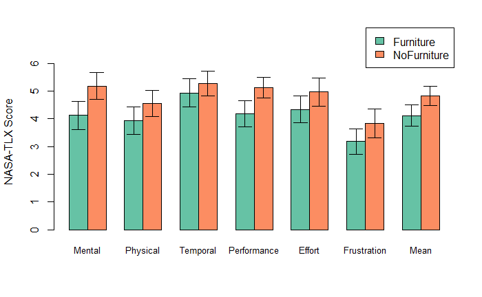

```r
mean_Chart <- aggregate(cbind(Mental, Physical, Temporal, Performance, Effort, Frustration, Mean)~Furniture , data=data.subjective , mean)
rownames(mean_Chart) <- mean_Chart[,1]
mean_Chart <- as.matrix(mean_Chart[,-1])

lim <- 1.2*max(mean_Chart)

error.bar <- function(x, y, upper, lower=upper, length=0.1,...){
  arrows(x,y+upper, x, y-lower, angle=90, code=3, length=length, ...)
}

stdev_Chart <- aggregate(cbind(Mental, Physical, Temporal, Performance, Effort, Frustration, Mean)~Furniture , data=data.subjective , sd)
rownames(stdev_Chart) <- stdev_Chart[,1]
se_Baseline <- as.matrix(stdev_Chart[,-1]) / sqrt(12)

ze_barplot <- barplot(mean_Chart , beside=T , legend.text=T,col=c("#66c2a5", "#fc8d62") , ylim=c(0,lim) , ylab="NASA-TLX Score", args.legend = list(x = "topright", inset = c(0, -0.15)), cex.names=0.8)
error.bar(ze_barplot, mean_Chart, se_Baseline)
```

For the NASA-TLX result analysis on the Furniture factor, the ANOVA test of Aligned Rank Transformed data shows significant effects for **Mental (p < 0.001, effect size partial eta-squared = 0.29)**, **Physical (p < 0.05, effect size partial eta-squared = 0.10)**, **Performance (p < 0.01, effect size partial eta-squared = 0.22)**, **Effort (p < 0.01, effect size partial eta-squared = 0.14)**, **Frustration (p < 0.05, effect size partial eta-squared = 0.10)**, and **overall mean (p < 0.001, effect size partial eta-squared = 0.25)**. The results show that the participants perform the best in the Furniture condition with the least mental effort, physical effort, and frustration.

Particularly, by analysing the effects on the four conditions using Friedman’s test and a post-hoc test using Wilcoxon tests with Bonferroni correction, we find significant differences between Condition **“Furniture-Regular”** and **“NoFurniture-Irregular”** on **Mental (p < 0.05, r = 0.34)**, **Physical (p < 0.05, r = 0.32)**, and **Overall mean (p < 0.05, r = 0.39)**. We also find significant differences between Condition **“NoFurniture-Irregular”** and **“Furniture-Irregular”** on the **Overall mean (p < 0.05, r = 0.31)**.

# 3 Participant Rating for different conditions

## 3.1 Load cleaned Rating data into the global environment

```r
load("data.rating.Rdata")
summary(data.rating)
```

```
  Condition              PID         Rating            Furniture        Layout
 Length:64          1      : 4   Min.   :1.000   Furniture  :32   Irregular:32
 Class :character   2      : 4   1st Qu.:2.000   NoFurniture:32   Regular  :32
 Mode  :character   3      : 4   Median :3.000
                    4      : 4   Mean   :3.031
                    5      : 4   3rd Qu.:4.000
                    6      : 4   Max.   :5.000
                    (Other):40
```

## 3.2 Check Normality

```r
shapiro.test(data.rating$Rating)
```

```
    Shapiro-Wilk normality test

data:  data.rating$Rating
W = 0.87362, p-value = 9.282e-06
```

p < 0.01, user rating data are not normally distributed. So we use ARTools to transform the data for multi-factor analysis. And then we use Friedman tests for single factor analysis.

```r
art.rating.both <- art(Rating ~ Furniture * Layout + Error(PID), data = data.rating)
```

## 3.3 Analyse Performance on the combination of two factors

We first check the homogenity using bartlett’s test.

### 3.3.1 Check Homogenity

```r
bartlett.test(Rating ~ interaction(Furniture,Layout), data = data.rating)
```

```
    Bartlett test of homogeneity of variances

data:  Rating by interaction(Furniture, Layout)
Bartlett's K-squared = 3.7538, df = 3, p-value = 0.2893
```

From the output, it can be seen that the p-value of **0.2893** is not less than the significance level of 0.05. This means that there is no evidence to suggest that the variance in **User Rating** is statistically significantly different **among different factors or the combination of factors.** Thus, we can assume the homogenity.

### 3.3.2 Two-way ANOVA

```r
model.rating.both <- anova(art.rating.both)
model.rating.both$part.eta.sq = with(model.rating.both, `Sum Sq`/(`Sum Sq` + `Sum Sq.res`))

model.rating.both
```

```
Analysis of Variance of Aligned Rank Transformed Data

Table Type: Repeated Measures Analysis of Variance Table (Type I)
Model: Repeated Measures (aov)
Response: art(Rating)

                   Error Df Df.res  F value     Pr(>F) part.eta.sq
1 Furniture        Withn  1     45 20.22016 4.8114e-05    0.310029 ***
2 Layout           Withn  1     45  2.47866    0.12241    0.052206
3 Furniture:Layout Withn  1     45  0.69189    0.40992    0.015142
---
Signif. codes:   0 ‘***’ 0.001 ‘**’ 0.01 ‘*’ 0.05 ‘.’ 0.1 ‘ ’ 1
```

From the output, it can be seen that we have significant main effects of Furniture **(p < 0.01)** with an effect size **partial eta-squared 0.31**. The effect size can be interpreted as a **large effect (eta-squared >= 0.14)**.

## 3.4 Addtional Analyse for User Rating on the Furniture Factor using Friedman’s test

Then, we use Friedman’s test to analyse the furniture factor.

```r
data.rating.furniture <- data.rating %>% dplyr::group_by(PID, Furniture) %>% dplyr::summarise(Rating = mean(Rating), .groups = "drop")
friedman.test(y=data.rating.furniture$Rating, groups=data.rating.furniture$Furniture, blocks=data.rating.furniture$PID)
```

```
    Friedman rank sum test

data:  data.rating.furniture$Rating, data.rating.furniture$Furniture and data.rating.furniture$PID
Friedman chi-squared = 4.5714, df = 1, p-value = 0.03251
```

A Friedman’s test revealed a significant effect of Furniture factor on Rating **(chi-squared = 4.6, p < 0.05)**.

```r
data.rating.furniture <- as.data.frame(data.rating.furniture)
data.rating.furniture %>% friedman_effsize(Rating ~ Furniture | PID)
```

|  | .y. | n | effsize | method | magnitude |
| --- | --- | --- | --- | --- | --- |
| 1 | Rating | 16 | 0.2857143 | Kendall W | small |

The effect size (Kendall’s W) for Furniture is 0.29. It implies a small effect size.

## 3.5 Addtional Analyse for User Rating on the Layout Factor using Friedman’s test

Then, we use Friedman’s test to analyse the layout factor.

```r
data.rating.layout <- data.rating %>% dplyr::group_by(PID, Layout) %>% dplyr::summarise(Rating = mean(Rating), .groups = "drop")
friedman.test(y=data.rating.layout$Rating, groups=data.rating.layout$Layout, blocks=data.rating.layout$PID)
```

```
    Friedman rank sum test

data:  data.rating.layout$Rating, data.rating.layout$Layout and data.rating.layout$PID
Friedman chi-squared = 0.81818, df = 1, p-value = 0.3657
```

From the output, it can be seen that the p value is 0.37 which is more than 0.05. It means that there is no evidence to suggest that the performance is statistically significantly different among different layouts.

## 3.6 Addtional Analyse for User Rating on the four conditions using Friedman’s test

Then, we use Friedman’s test to analyse the four conditions.

```r
data.rating.condition <- data.rating %>% dplyr::group_by(PID, Condition) %>% dplyr::summarise(Rating = mean(Rating), .groups = "drop")
friedman.test(y=data.rating.condition$Rating, groups=data.rating.condition$Condition, blocks=data.rating.condition$PID)
```

```
    Friedman rank sum test

data:  data.rating.condition$Rating, data.rating.condition$Condition and data.rating.condition$PID
Friedman chi-squared = 13.055, df = 3, p-value = 0.004519
```

A Friedman’s test revealed a significant effect of four conditions on User Rating **(chi-squared = 13.1, p < 0.01)**.

```r
data.rating.condition <- as.data.frame(data.rating.condition)
data.rating.condition %>% friedman_effsize(Rating ~ Condition | PID)
```

|  | .y. | n | effsize | method | magnitude |
| --- | --- | --- | --- | --- | --- |
| 1 | Rating | 16 | 0.2719828 | Kendall W | small |

The effect size (Kendall’s W) is 0.27. It implies a small effect size.

```r
pairwise.wilcox.test(data.rating.condition$Rating, data.rating.condition$Condition, p.adj="bonferroni", exact=F, paired=T)
```

```
    Pairwise comparisons using Wilcoxon signed rank test with continuity correction

data:  data.rating.condition$Rating and data.rating.condition$Condition

                      Furniture+Irregular Furniture+Regular NoFurniture+Irregular
Furniture+Regular     1.000               -                 -
NoFurniture+Irregular 0.038               0.013             -
NoFurniture+Regular   0.636               0.147             0.466

P value adjustment method: bonferroni
```

```r
wilcox_test(Rating ~ factor(Condition), data=data.rating.condition[data.rating.condition$Condition=="Furniture+Regular"|data.rating.condition$Condition=="NoFurniture+Irregular",], distribution="exact")
```

```
    Exact Wilcoxon-Mann-Whitney Test

data:  Rating by factor(Condition) (Furniture+Regular, NoFurniture+Irregular)
Z = 3.7797, p-value = 6.439e-05
alternative hypothesis: true mu is not equal to 0
```

```r
3.7797 / sqrt(32)
```

```
[1] 0.6681629
```

```r
wilcox_test(Rating ~ factor(Condition), data=data.rating.condition[data.rating.condition$Condition=="Furniture+Irregular"|data.rating.condition$Condition=="NoFurniture+Irregular",], distribution="exact")
```

```
    Exact Wilcoxon-Mann-Whitney Test

data:  Rating by factor(Condition) (Furniture+Irregular, NoFurniture+Irregular)
Z = 3.1177, p-value = 0.001435
alternative hypothesis: true mu is not equal to 0
```

```r
3.1177 / sqrt(32)
```

```
[1] 0.5511367
```

A post-hoc test using Wilcoxon tests with Bonferroni correction showed a significant differences between Condition “Furniture-Regular” and “NoFurniture-Irregular” (p < 0.05, r = 0.67) and between Condition “NoFurniture-Irregular” and “Furniture-Irregular” (p < 0.05, r = 0.55).

## 3.7 User Rating Conclusion and Visualisation

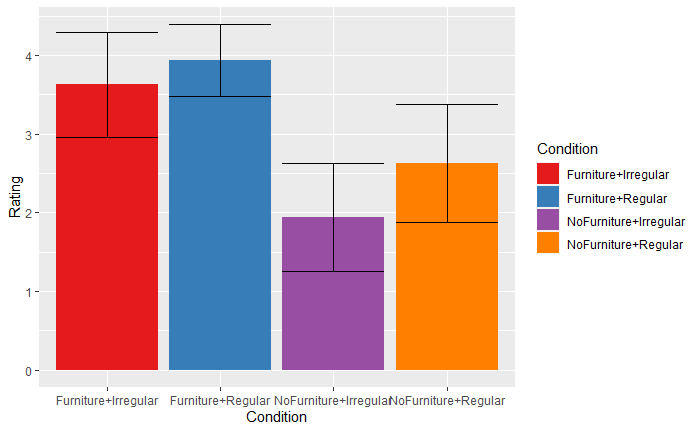

```r
d <- Rmisc::summarySE(data.rating, measurevar = "Rating", groupvars = c("Condition"))
ggplot(d, aes(x = Condition, y = Rating, fill = Condition)) + geom_bar(stat = "identity") + geom_errorbar(aes(ymin=Rating-ci, ymax=Rating+ci)) + scale_fill_manual(values=c("#e41a1c", "#377eb8", "#984ea3", "#ff7f00"))
```

For the quantitative analysis on the User Ratings of two factors, we can see that from the ANOVA test of Aligned Rank Transformed data, we have significant main effects of **Furniture (p < 0.01)** with an **effect size partial eta-squared 0.31**. The effect size can be interpreted as **a large effect (eta-squared >= 0.14)**. An additional Friedman’s test proves the significant effect of Furniture factor **(p < 0.05, chi-squared = 4.6, effect size Kendall’s W = 0.29)**.

Another Friedman’s test and a post-hoc Wilcoxon tests with Bonferroni correction on the User Ratings of four conditions shows that there is a significant differences between Condition **“Furniture-Regular”** and **“NoFurniture-Irregular”** **(p < 0.05, r = 0.67)** and between Condition **“NoFurniture-Irregular”** and **“Furniture-Irregular”** **(p < 0.05, r = 0.55)**.

# 4 Recall Time Results

## 4.1 R Libraries

```r
library(dplyr)
library(ggpubr)
library(rstatix)
library(effectsize)
library(pwr)
```

## 4.2 Load raw Recall Time data into global environment

```r
load("data.recallTime.raw.Rdata")
summary(data.recallTime.raw)
```

```
      PID         TrialID           Furniture         Layout                     Condition    AnswerTime
 1      : 20   1      : 16   HasFurniture:160   Irregular:160   HasFurniture-Irregular:80   Min.   : 11.76
 2      : 20   10     : 16   NoFurniture :160   Regular  :160   HasFurniture-Regular  :80   1st Qu.: 20.21
 3      : 20   11     : 16                                      NoFurniture-Irregular :80   Median : 24.74
 4      : 20   12     : 16                                      NoFurniture-Regular   :80   Mean   : 28.17
 5      : 20   13     : 16                                                                  3rd Qu.: 31.84
 6      : 20   14     : 16                                                                  Max.   :107.30
 (Other):200   (Other):224
```

## 4.3 Data Wrangling

### 4.3.1 Visualizing Outliers

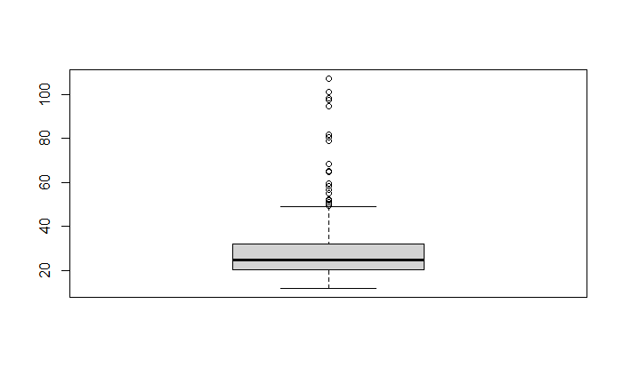

```r
boxplot(data.recallTime.raw$AnswerTime)
```

### 4.3.2 Finding Outliers

```r
Q <- quantile(data.recallTime.raw$AnswerTime, probs=c(.25, .75), na.rm = FALSE)
iqr <- IQR(data.recallTime.raw$AnswerTime)
up <-  Q[2]+1.5*iqr # Upper Range
outliers <- subset(data.recallTime.raw, data.recallTime.raw$AnswerTime >= up)
outliers
```

|  | PID | TrialID | Furniture | Layout | Condition | AnswerTime |
| --- | --- | --- | --- | --- | --- | --- |
| 22 | 2 | 2 | NoFurniture | Regular | NoFurniture-Regular | 51.64 |
| 65 | 4 | 5 | NoFurniture | Irregular | NoFurniture-Irregular | 51.04 |
| 67 | 4 | 7 | HasFurniture | Irregular | HasFurniture-Irregular | 64.72 |
| 81 | 5 | 1 | HasFurniture | Regular | HasFurniture-Regular | 58.14 |
| 249 | 13 | 9 | NoFurniture | Irregular | NoFurniture-Irregular | 54.88 |
| 257 | 13 | 17 | HasFurniture | Irregular | HasFurniture-Irregular | 52.30 |
| 259 | 13 | 19 | HasFurniture | Irregular | HasFurniture-Irregular | 78.94 |
| 281 | 15 | 1 | NoFurniture | Irregular | NoFurniture-Irregular | 107.30 |
| 282 | 15 | 2 | NoFurniture | Irregular | NoFurniture-Irregular | 98.32 |
| 283 | 15 | 3 | NoFurniture | Irregular | NoFurniture-Irregular | 94.62 |

[output cut: 10 more lines]

We found 20 trials where participants spent more than usual time (> 49.3s) during the recall phase, causing the data not valid. We then remove those 20 trials from the raw data.

### 4.3.3 Eliminating Outliers

```r
data.recallTime.eliminated <- subset(data.recallTime.raw, data.recallTime.raw$AnswerTime < up)
str(data.recallTime.eliminated)
```

```
'data.frame':   300 obs. of  6 variables:
 $ PID       : Factor w/ 16 levels "1","2","3","4",..: 1 1 1 1 1 1 1 1 1 1 ...
 $ TrialID   : Factor w/ 20 levels "1","10","11",..: 1 12 14 15 16 17 18 19 20 2 ...
 $ Furniture : Factor w/ 2 levels "HasFurniture",..: 1 1 1 1 1 2 2 2 2 2 ...
 $ Layout    : Factor w/ 2 levels "Irregular","Regular": 2 2 2 2 2 2 2 2 2 2 ...
 $ Condition : Factor w/ 4 levels "HasFurniture-Irregular",..: 2 2 2 2 2 4 4 4 4 4 ...
 $ AnswerTime: num  34.1 15.3 20.7 22.2 26 ...
```

```r
summary(data.recallTime.eliminated)
```

```
      PID         TrialID           Furniture         Layout                     Condition    AnswerTime
 1      : 20   10     : 16   HasFurniture:150   Irregular:146   HasFurniture-Irregular:73   Min.   :11.76
 3      : 20   11     : 16   NoFurniture :150   Regular  :154   HasFurniture-Regular  :77   1st Qu.:19.91
 6      : 20   12     : 16                                      NoFurniture-Irregular :73   Median :24.07
 7      : 20   13     : 16                                      NoFurniture-Regular   :77   Mean   :25.31
 8      : 20   14     : 16                                                                  3rd Qu.:29.68
 9      : 20   18     : 16                                                                  Max.   :48.92
 (Other):180   (Other):204
```

After removing, we have 300 observations left for further analysis.

### 4.3.4 Aggregate Recall Time Data

```r
data.recallTime.eliminated = subset(data.recallTime.eliminated, select = -TrialID)
data.recallTime <- data.recallTime.eliminated %>% group_by(PID, Condition) %>% mutate(AnswerTime = mean(AnswerTime)) %>% ungroup()
data.recallTime <- distinct(data.recallTime)
data.recallTime.female <- filter(data.recallTime, as.integer(data.recallTime$PID) <= 8)
data.recallTime.male  <- filter(data.recallTime, as.integer(data.recallTime$PID) > 8)
summary(data.recallTime)
```

```
      PID            Furniture        Layout                    Condition    AnswerTime
 1      : 4   HasFurniture:32   Irregular:31   HasFurniture-Irregular:16   Min.   :14.19
 2      : 4   NoFurniture :31   Regular  :32   HasFurniture-Regular  :16   1st Qu.:21.83
 3      : 4                                    NoFurniture-Irregular :15   Median :25.31
 4      : 4                                    NoFurniture-Regular   :16   Mean   :25.55
 5      : 4                                                                3rd Qu.:28.71
 6      : 4                                                                Max.   :41.85
 (Other):39
```

### 4.3.5 Test normality in the main dataset

```r
shapiro.test(data.recallTime$AnswerTime)
```

```
    Shapiro-Wilk normality test

data:  data.recallTime$AnswerTime
W = 0.98375, p-value = 0.5727
```

We can clearly see from the result that p value is > 0.05, which means that the dataare normally distributed. So, we use ANOVA test for different dependent variables.

### 4.3.6 Analysis of Two Factors combination

#### 4.3.6.1 Check Homogenity

```r
bartlett.test(AnswerTime ~ interaction(Furniture, Layout), data = data.recallTime)
```

```
    Bartlett test of homogeneity of variances

data:  AnswerTime by interaction(Furniture, Layout)
Bartlett's K-squared = 1.9219, df = 3, p-value = 0.5888
```

From the output, it can be seen that the p-value of **0.5888** is not less than the significance level of 0.05. This means that there is no evidence to suggest that the variance in **Recall Time** is statistically significantly different among different **factors or the combination of factors**. Thus, we can assume the homogenity.

#### 4.3.6.2 Two-way Repeated measures ANOVA

```r
model.recallTime <- aov(AnswerTime ~ Furniture * Layout + Error(PID), data = data.recallTime)

summary(model.recallTime)
```

```
Error: PID
          Df Sum Sq Mean Sq F value Pr(>F)
Furniture  1  403.8   403.8   7.166 0.0181 *
Residuals 14  788.9    56.3
---
Signif. codes:  0 ‘***’ 0.001 ‘**’ 0.01 ‘*’ 0.05 ‘.’ 0.1 ‘ ’ 1

Error: Within
                 Df Sum Sq Mean Sq F value Pr(>F)
Furniture         1    6.9    6.92   0.454  0.504
Layout            1    0.2    0.19   0.012  0.912
Furniture:Layout  1   39.0   38.96   2.555  0.117
Residuals        44  671.0   15.25
```

### 4.3.7 Analysis of Furniture Factor

#### 4.3.7.1 Unpaired T Test

```r
t.Furniture.RecallTime <- t.test(data.recallTime[data.recallTime["Furniture"]=="HasFurniture",5], data.recallTime[data.recallTime['Furniture']=="NoFurniture",5])
t.Furniture.RecallTime
```

```
    Welch Two Sample t-test

data:  data.recallTime[data.recallTime["Furniture"] == "HasFurniture", 5] and data.recallTime[data.recallTime["Furniture"] == "NoFurniture", 5]
t = 0.72458, df = 57.39, p-value = 0.4717
alternative hypothesis: true difference in means is not equal to 0
95 percent confidence interval:
 -1.800061  3.841842
sample estimates:
mean of x mean of y
 26.05695  25.03606
```

From the Unpaired T Test above, we can see that there is no significant effect on Recall time between two furniture conditions.

#### 4.3.7.2 Visualisation

```r
d <- Rmisc::summarySE(data.recallTime, measurevar = "AnswerTime", groupvars = c("Furniture"))
d
```

| Furniture | N | AnswerTime | sd | se | ci |
| --- | --- | --- | --- | --- | --- |
| HasFurniture | 32 | 26.05695 | 4.931250 | 0.871730 | 1.777905 |
| NoFurniture | 31 | 25.03606 | 6.162931 | 1.106895 | 2.260581 |

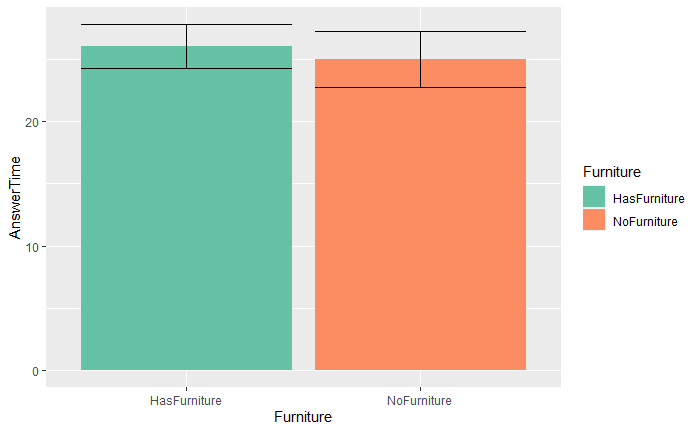

```r
ggplot(d, aes(x = Furniture, y = AnswerTime, fill = Furniture)) + geom_bar(stat = "identity") + geom_errorbar(aes(ymin=AnswerTime-ci, ymax=AnswerTime+ci)) + scale_fill_manual(values=c("#66c2a5", "#fc8d62"))
```

### 4.3.8 Analysis of Layout Factor

#### 4.3.8.1 Unpaired T Test

```r
t.Layout.RecallTime <- t.test(data.recallTime[data.recallTime["Layout"]=="Regular",5], data.recallTime[data.recallTime['Layout']=="Irregular",5])
t.Layout.RecallTime
```

```
    Welch Two Sample t-test

data:  data.recallTime[data.recallTime["Layout"] == "Regular", 5] and data.recallTime[data.recallTime["Layout"] == "Irregular", 5]
t = 0.16739, df = 60.948, p-value = 0.8676
alternative hypothesis: true difference in means is not equal to 0
95 percent confidence interval:
 -2.582852  3.054768
sample estimates:
mean of x mean of y
 25.67072  25.43476
```

From the Unpaired T Test above, we can see that there is no significant effect on Recall time between two layout conditions.

#### 4.3.8.2 Visualisation

```r
d <- Rmisc::summarySE(data.recallTime, measurevar = "AnswerTime", groupvars = c("Layout"))
d
```

| Layout | N | AnswerTime | sd | se | ci |
| --- | --- | --- | --- | --- | --- |
| Irregular | 31 | 25.43476 | 5.585054 | 1.0031053 | 2.048614 |
| Regular | 32 | 25.67072 | 5.602519 | 0.9903949 | 2.019924 |

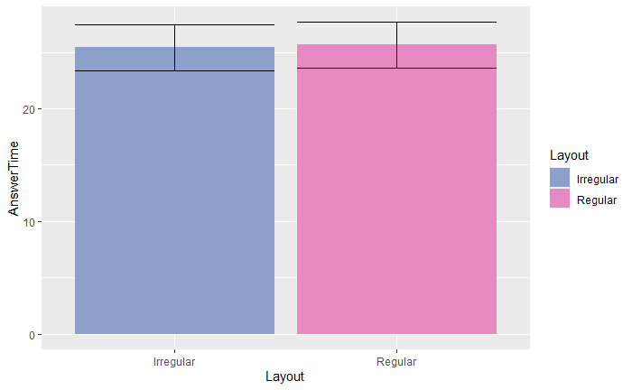

```r
ggplot(d, aes(x = Layout, y = AnswerTime, fill = Layout)) + geom_bar(stat = "identity") + geom_errorbar(aes(ymin=AnswerTime-ci, ymax=AnswerTime+ci)) + scale_fill_manual(values=c("#8da0cb", "#e78ac3"))
```

### 4.3.9 Analysis of Four Conditions

#### 4.3.9.1 Check Homogenity

```r
bartlett.test(AnswerTime ~ Condition, data = data.recallTime)
```

```
    Bartlett test of homogeneity of variances

data:  AnswerTime by Condition
Bartlett's K-squared = 1.9219, df = 3, p-value = 0.5888
```

From the output, it can be seen that the p-value of **0.5888** is not less than the significance level of 0.05. This means that there is no evidence to suggest that the variance in **Recall Time** is statistically significantly different among different **conditions**. Thus, we can assume the homogenity.

#### 4.3.9.2 One-way Repeated measures ANOVA

```r
aov <- aov(AnswerTime ~ Condition, data.recallTime)
summary(aov)
```

```
            Df Sum Sq Mean Sq F value Pr(>F)
Condition    3   40.1   13.36   0.422  0.738
Residuals   59 1869.6   31.69
```

From the one-way repeated measures ANOVA results above, we cannot find a strong significant main effect **among the four conditions (p = 0.738)**.

#### 4.3.9.3 Visualisation

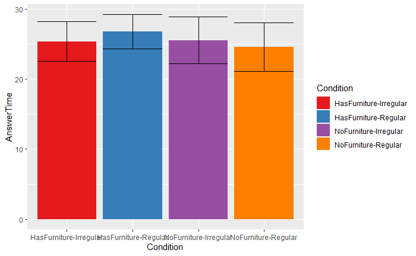

```r
d <- Rmisc::summarySE(data.recallTime, measurevar = "AnswerTime", groupvars = c("Condition"))
ggplot(d, aes(x = Condition, y = AnswerTime, fill = Condition)) + geom_bar(stat = "identity") + geom_errorbar(aes(ymin=AnswerTime-ci, ymax=AnswerTime+ci)) + scale_fill_manual(values=c("#e41a1c", "#377eb8", "#984ea3", "#ff7f00"))
```

## 4.4 Recall Time Conclusion and Visualisation

We don’t find any evidence to suggest that the Furniture factor or Layout factor has a main effect on the Recall Time.

# 5 Locomotion Results

## 5.1 R Libraries

```r
library(dplyr)
library(ggpubr)
library(rstatix)
```

## 5.2 Load Locomotion data into global environment

```r
load("data.locomotion.furniture.learning.Rdata")
summary(data.locomotion.furniture.learning)
```

```
      PID           Furniture     Rotation       Distance
 1      : 2   Furniture  :16   Min.   :1056   Min.   : 7.914
 2      : 2   NoFurniture:16   1st Qu.:1445   1st Qu.: 8.611
 3      : 2                    Median :1863   Median : 9.447
 4      : 2                    Mean   :1862   Mean   : 9.761
 5      : 2                    3rd Qu.:2290   3rd Qu.:10.570
 6      : 2                    Max.   :2949   Max.   :14.975
 (Other):20
```

```r
load("data.locomotion.furniture.recall.Rdata")
summary(data.locomotion.furniture.recall)
```

```
      PID           Furniture     Rotation       Distance
 1      : 2   Furniture  :16   Min.   :1251   Min.   : 8.276
 2      : 2   NoFurniture:16   1st Qu.:2012   1st Qu.: 9.750
 3      : 2                    Median :2511   Median :10.626
 4      : 2                    Mean   :2564   Mean   :11.174
 5      : 2                    3rd Qu.:2909   3rd Qu.:11.958
 6      : 2                    Max.   :6255   Max.   :22.826
 (Other):20
```

```r
load("data.locomotion.layout.Rdata")
summary(data.locomotion.layout)
```

```
      PID           Layout      Rotation       Distance
 1      : 2   Irregular:16   Min.   :1027   Min.   : 7.921
 2      : 2   Regular  :16   1st Qu.:1470   1st Qu.: 8.497
 3      : 2                  Median :1894   Median : 9.237
 4      : 2                  Mean   :1870   Mean   : 9.754
 5      : 2                  3rd Qu.:2183   3rd Qu.:10.891
 6      : 2                  Max.   :3238   Max.   :13.347
 (Other):20
```

```r
load("data.locomotion.condition.learning.Rdata")
summary(data.locomotion.condition.learning)
```

```
      PID                     Condition     Rotation         Distance
 1      : 4   Furniture-Irregular  :16   Min.   : 850.2   Min.   : 7.586
 2      : 4   Furniture-Regular    :16   1st Qu.:1261.7   1st Qu.: 8.462
 3      : 4   NoFurniture-Irregular:16   Median :1814.3   Median : 9.233
 4      : 4   NoFurniture-Regular  :16   Mean   :1866.2   Mean   : 9.751
 5      : 4                              3rd Qu.:2306.1   3rd Qu.:10.583
 6      : 4                              Max.   :4131.9   Max.   :17.027
 (Other):40
```

```r
load("data.locomotion.condition.recall.Rdata")
summary(data.locomotion.condition.recall)
```

```
      PID                     Condition     Rotation       Distance
 1      : 4   Furniture-Irregular  :16   Min.   :1025   Min.   : 7.772
 2      : 4   Furniture-Regular    :16   1st Qu.:1738   1st Qu.: 9.416
 3      : 4   NoFurniture-Irregular:16   Median :2509   Median :10.344
 4      : 4   NoFurniture-Regular  :16   Mean   :2566   Mean   :11.121
 5      : 4                              3rd Qu.:2961   3rd Qu.:12.233
 6      : 4                              Max.   :7063   Max.   :26.287
 (Other):40
```

## 5.3 Furniture Factor Analysis

### 5.3.1 Check Outliers and remove them

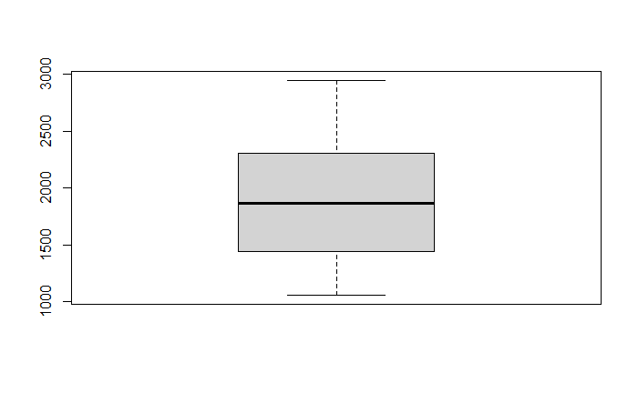

```r
boxplot(data.locomotion.furniture.learning$Rotation)
```

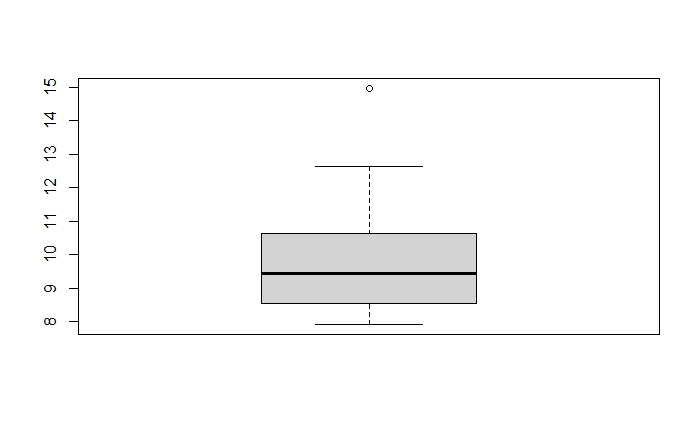

```r
boxplot(data.locomotion.furniture.learning$Distance)
```

```r
Q <- quantile(data.locomotion.furniture.learning$Distance, probs=c(.25, .75), na.rm = FALSE)
iqr <- IQR(data.locomotion.furniture.learning$Distance)
up <-  Q[2]+1.5*iqr # Upper Range

data.locomotion.furniture.learning.eliminated <- subset(data.locomotion.furniture.learning, data.locomotion.furniture.learning$Distance < up)
summary(data.locomotion.furniture.learning.eliminated)
```

```
      PID           Furniture     Rotation       Distance
 1      : 2   Furniture  :15   Min.   :1056   Min.   : 7.914
 2      : 2   NoFurniture:16   1st Qu.:1438   1st Qu.: 8.541
 3      : 2                    Median :1857   Median : 9.309
 4      : 2                    Mean   :1853   Mean   : 9.593
 5      : 2                    3rd Qu.:2307   3rd Qu.:10.483
 6      : 2                    Max.   :2949   Max.   :12.628
 (Other):19
```

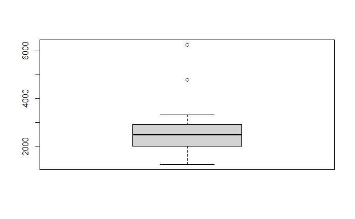

```r
boxplot(data.locomotion.furniture.recall$Rotation)
```

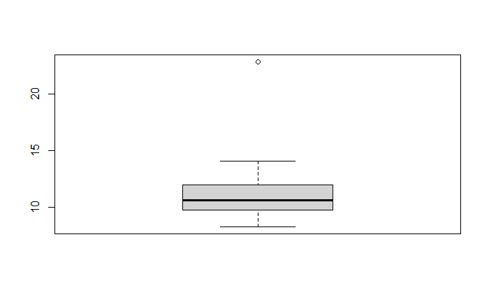

```r
boxplot(data.locomotion.furniture.recall$Distance)
```

```r
Q <- quantile(data.locomotion.furniture.recall$Distance, probs=c(.25, .75), na.rm = FALSE)
iqr <- IQR(data.locomotion.furniture.recall$Distance)
up <-  Q[2]+1.5*iqr # Upper Range

data.locomotion.furniture.recall.eliminated <- subset(data.locomotion.furniture.recall, data.locomotion.furniture.recall$Distance < up)
summary(data.locomotion.furniture.recall.eliminated)
```

```
      PID           Furniture     Rotation       Distance
 1      : 2   Furniture  :15   Min.   :1251   Min.   : 8.276
 2      : 2   NoFurniture:16   1st Qu.:2006   1st Qu.: 9.732
 3      : 2                    Median :2437   Median :10.578
 4      : 2                    Mean   :2445   Mean   :10.798
 5      : 2                    3rd Qu.:2881   3rd Qu.:11.823
 6      : 2                    Max.   :4791   Max.   :14.081
 (Other):19
```

### 5.3.2 Check normality

```r
shapiro.test(data.locomotion.furniture.learning.eliminated$Rotation)
```

```
    Shapiro-Wilk normality test

data:  data.locomotion.furniture.learning.eliminated$Rotation
W = 0.96749, p-value = 0.4528
```

```r
shapiro.test(data.locomotion.furniture.learning.eliminated$Distance)
```

```
    Shapiro-Wilk normality test

data:  data.locomotion.furniture.learning.eliminated$Distance
W = 0.94805, p-value = 0.1379
```

```r
shapiro.test(data.locomotion.furniture.recall.eliminated$Rotation)
```

```
    Shapiro-Wilk normality test

data:  data.locomotion.furniture.recall.eliminated$Rotation
W = 0.93568, p-value = 0.06272
```

```r
shapiro.test(data.locomotion.furniture.recall.eliminated$Distance)
```

```
    Shapiro-Wilk normality test

data:  data.locomotion.furniture.recall.eliminated$Distance
W = 0.96153, p-value = 0.3201
```

Both Rotation data and Distance data are normally distributed. So we use t test to compare the two groups in Furniture factor

### 5.3.3 An unpaired t test

```r
t.Furniture.learning.Rotation <- t.test(data.locomotion.furniture.learning.eliminated[data.locomotion.furniture.learning.eliminated["Furniture"]=="Furniture",3], data.locomotion.furniture.learning.eliminated[data.locomotion.furniture.learning.eliminated['Furniture']=="NoFurniture",3])
t.Furniture.learning.Rotation
```

```
    Welch Two Sample t-test

data:  data.locomotion.furniture.learning.eliminated[data.locomotion.furniture.learning.eliminated["Furniture"] == "Furniture", 3] and data.locomotion.furniture.learning.eliminated[data.locomotion.furniture.learning.eliminated["Furniture"] == "NoFurniture", 3]
t = 0.89424, df = 25.303, p-value = 0.3796
alternative hypothesis: true difference in means is not equal to 0
95 percent confidence interval:
 -217.5201  551.7224
sample estimates:
mean of x mean of y
 1938.946  1771.845
```

```r
t.Furniture.learning.Distance <- t.test(data.locomotion.furniture.learning.eliminated[data.locomotion.furniture.learning.eliminated["Furniture"]=="Furniture",4], data.locomotion.furniture.learning.eliminated[data.locomotion.furniture.learning.eliminated['Furniture']=="NoFurniture",4])
t.Furniture.learning.Distance
```

```
    Welch Two Sample t-test

data:  data.locomotion.furniture.learning.eliminated[data.locomotion.furniture.learning.eliminated["Furniture"] == "Furniture", 4] and data.locomotion.furniture.learning.eliminated[data.locomotion.furniture.learning.eliminated["Furniture"] == "NoFurniture", 4]
t = 0.55073, df = 26.941, p-value = 0.5864
alternative hypothesis: true difference in means is not equal to 0
95 percent confidence interval:
 -0.6713274  1.1638507
sample estimates:
mean of x mean of y
 9.719889  9.473627
```

```r
t.Furniture.recall.Rotation <- t.test(data.locomotion.furniture.recall.eliminated[data.locomotion.furniture.recall.eliminated["Furniture"]=="Furniture",3], data.locomotion.furniture.recall.eliminated[data.locomotion.furniture.recall.eliminated['Furniture']=="NoFurniture",3])
t.Furniture.recall.Rotation
```

```
    Welch Two Sample t-test

data:  data.locomotion.furniture.recall.eliminated[data.locomotion.furniture.recall.eliminated["Furniture"] == "Furniture", 3] and data.locomotion.furniture.recall.eliminated[data.locomotion.furniture.recall.eliminated["Furniture"] == "NoFurniture", 3]
t = -0.83494, df = 26.847, p-value = 0.4111
alternative hypothesis: true difference in means is not equal to 0
95 percent confidence interval:
 -750.6561  316.5145
sample estimates:
mean of x mean of y
 2332.649  2549.720
```

```r
t.Furniture.recall.Distance <- t.test(data.locomotion.furniture.recall.eliminated[data.locomotion.furniture.recall.eliminated["Furniture"]=="Furniture",4], data.locomotion.furniture.recall.eliminated[data.locomotion.furniture.recall.eliminated['Furniture']=="NoFurniture",4])
t.Furniture.recall.Distance
```

```
    Welch Two Sample t-test

data:  data.locomotion.furniture.recall.eliminated[data.locomotion.furniture.recall.eliminated["Furniture"] == "Furniture", 4] and data.locomotion.furniture.recall.eliminated[data.locomotion.furniture.recall.eliminated["Furniture"] == "NoFurniture", 4]
t = -0.75028, df = 28.641, p-value = 0.4592
alternative hypothesis: true difference in means is not equal to 0
95 percent confidence interval:
 -1.6237630  0.7525175
sample estimates:
mean of x mean of y
 10.57311  11.00874
```

With a Welch’s t test, we found no significant effect for Furniture factor on Head Rotation and Walking Distance.

### 5.3.4 Visualisation

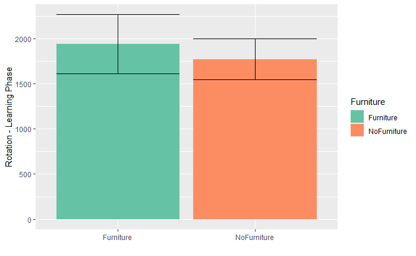

```r
d <- Rmisc::summarySE(data.locomotion.furniture.learning.eliminated, measurevar = "Rotation", groupvars = c("Furniture"))
ggplot(d, aes(x = Furniture, y = Rotation, fill = Furniture)) + geom_bar(stat = "identity") + geom_errorbar(aes(ymin=Rotation-ci, ymax=Rotation+ci)) + scale_fill_manual(values=c("#66c2a5", "#fc8d62")) + labs(y = "Rotation - Learning Phase", x = "")
```

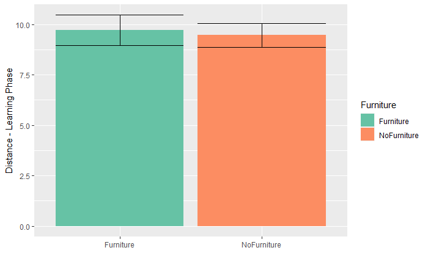

```r
d2 <- Rmisc::summarySE(data.locomotion.furniture.learning.eliminated, measurevar = "Distance", groupvars = c("Furniture"))
ggplot(d2, aes(x = Furniture, y = Distance, fill = Furniture)) + geom_bar(stat = "identity") + geom_errorbar(aes(ymin=Distance-ci, ymax=Distance+ci)) + scale_fill_manual(values=c("#66c2a5", "#fc8d62")) + labs(y = "Distance - Learning Phase", x = "")
```

[figure not shown]

```r
d3 <- Rmisc::summarySE(data.locomotion.furniture.recall.eliminated, measurevar = "Rotation", groupvars = c("Furniture"))
ggplot(d, aes(x = Furniture, y = Rotation, fill = Furniture)) + geom_bar(stat = "identity") + geom_errorbar(aes(ymin=Rotation-ci, ymax=Rotation+ci)) + scale_fill_manual(values=c("#66c2a5", "#fc8d62")) + labs(y = "Rotation - Recall Phase", x = "")
```

[figure not shown]

```r
d4 <- Rmisc::summarySE(data.locomotion.furniture.recall.eliminated, measurevar = "Distance", groupvars = c("Furniture"))
ggplot(d2, aes(x = Furniture, y = Distance, fill = Furniture)) + geom_bar(stat = "identity") + geom_errorbar(aes(ymin=Distance-ci, ymax=Distance+ci)) + scale_fill_manual(values=c("#66c2a5", "#fc8d62")) + labs(y = "Distance - Recall Phase", x = "")
```

## 5.4 Layout Factor Analysis

### 5.4.1 Check Outliers and remove them

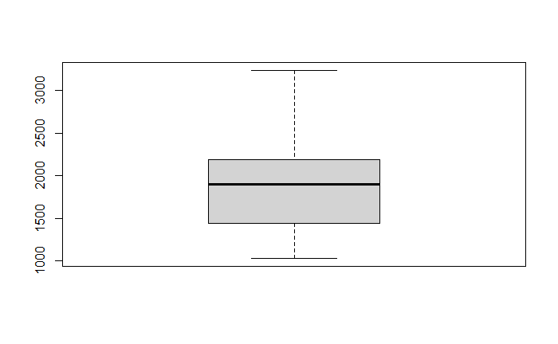

```r
boxplot(data.locomotion.layout$Rotation)
```

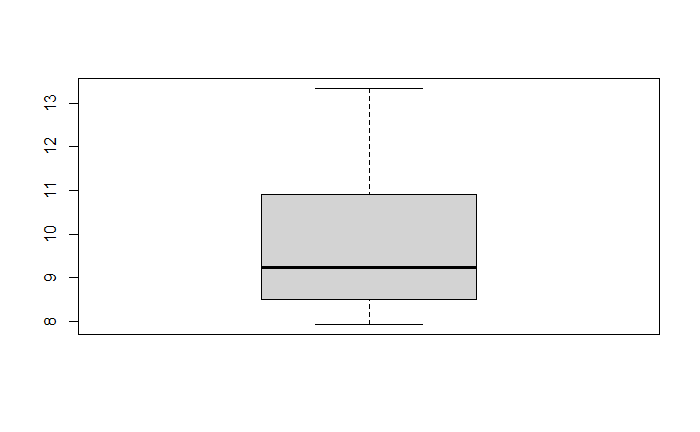

```r
boxplot(data.locomotion.layout$Distance)
```

### 5.4.2 Check normality

```r
shapiro.test(data.locomotion.layout$Rotation)
```

```
    Shapiro-Wilk normality test

data:  data.locomotion.layout$Rotation
W = 0.95641, p-value = 0.2185
```

```r
shapiro.test(data.locomotion.layout$Distance)
```

```
    Shapiro-Wilk normality test

data:  data.locomotion.layout$Distance
W = 0.88823, p-value = 0.003149
```

The Rotation data are normally distributed, while the distance data are not normally distributed. So we use t test to compare the two groups in Furniture factor for head rotations, while using Mann-Whitney’s U test for walking distance.

### 5.4.3 A paired t test

```r
t.Layout.Rotation <- t.test(data.locomotion.layout[data.locomotion.layout["Layout"]=="Regular",3], data.locomotion.layout[data.locomotion.layout['Layout']=="Irregular",3], paired = T)
t.Layout.Rotation
```

```
    Paired t-test

data:  data.locomotion.layout[data.locomotion.layout["Layout"] == "Regular", 3] and data.locomotion.layout[data.locomotion.layout["Layout"] == "Irregular", 3]
t = 1.2705, df = 15, p-value = 0.2233
alternative hypothesis: true difference in means is not equal to 0
95 percent confidence interval:
 -149.8986  592.2968
sample estimates:
mean of the differences
               221.1991
```

### 5.4.4 A Mann-Whitney’s U test

```r
W.Layout.Distance <- wilcox.test(data.locomotion.layout[data.locomotion.layout["Layout"]=="Regular",4], data.locomotion.layout[data.locomotion.layout['Layout']=="Irregular",4])
W.Layout.Distance
```

```
    Wilcoxon rank sum exact test

data:  data.locomotion.layout[data.locomotion.layout["Layout"] == "Regular", 4] and data.locomotion.layout[data.locomotion.layout["Layout"] == "Irregular", 4]
W = 140, p-value = 0.6689
alternative hypothesis: true location shift is not equal to 0
```

With a Mann-Whitney’s U test, we found no significant effect for Layout factor on Walking Distance.

### 5.4.5 Visualisation

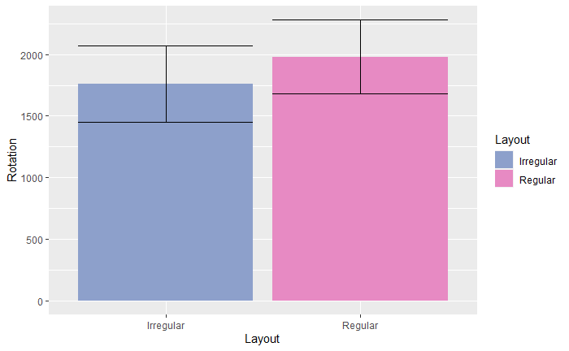

```r
d <- Rmisc::summarySE(data.locomotion.layout, measurevar = "Rotation", groupvars = c("Layout"))
ggplot(d, aes(x = Layout, y = Rotation, fill = Layout)) + geom_bar(stat = "identity") + geom_errorbar(aes(ymin=Rotation-ci, ymax=Rotation+ci)) + scale_fill_manual(values=c("#8da0cb", "#e78ac3"))
```

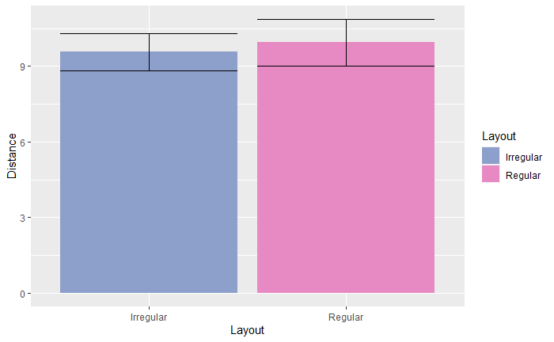

```r
d2 <- Rmisc::summarySE(data.locomotion.layout, measurevar = "Distance", groupvars = c("Layout"))
ggplot(d2, aes(x = Layout, y = Distance, fill = Layout)) + geom_bar(stat = "identity") + geom_errorbar(aes(ymin=Distance-ci, ymax=Distance+ci)) + scale_fill_manual(values=c("#8da0cb", "#e78ac3"))
```

## 5.5 Four Conditions Analysis

### 5.5.1 Check Outliers and remove them

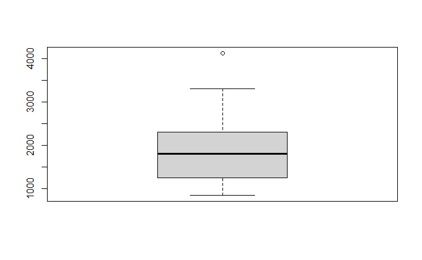

```r
boxplot(data.locomotion.condition.learning$Rotation)
```

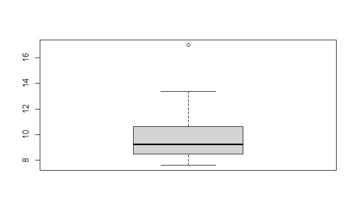

```r
boxplot(data.locomotion.condition.learning$Distance)
```

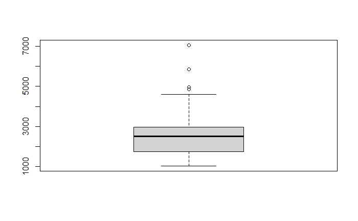

```r
Q <- quantile(data.locomotion.condition.learning$Rotation, probs=c(.25, .75), na.rm = FALSE)
iqr <- IQR(data.locomotion.condition.learning$Rotation)
up <-  Q[2]+1.5*iqr # Upper Range

data.locomotion.condition.learning.eliminated <- subset(data.locomotion.condition.learning, data.locomotion.condition.learning$Rotation < up)


Q2 <- quantile(data.locomotion.condition.learning.eliminated$Distance, probs=c(.25, .75), na.rm = FALSE)
iqr2 <- IQR(data.locomotion.condition.learning.eliminated$Distance)
up2 <-  Q2[2]+1.5*iqr2 # Upper Range
data.locomotion.condition.learning.eliminated <- subset(data.locomotion.condition.learning.eliminated, data.locomotion.condition.learning.eliminated$Distance < up2)

boxplot(data.locomotion.condition.recall$Rotation)
```

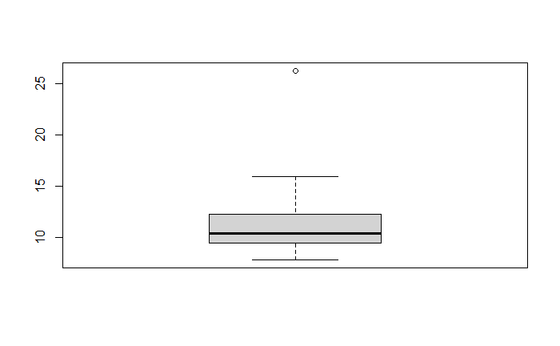

```r
boxplot(data.locomotion.condition.recall$Distance)
```

```r
Q3 <- quantile(data.locomotion.condition.recall$Rotation, probs=c(.25, .75), na.rm = FALSE)
iqr3 <- IQR(data.locomotion.condition.recall$Rotation)
up3 <-  Q3[2]+1.5*iqr3 # Upper Range

data.locomotion.condition.recall.eliminated <- subset(data.locomotion.condition.recall, data.locomotion.condition.recall$Rotation < up3)


Q4 <- quantile(data.locomotion.condition.recall.eliminated$Distance, probs=c(.25, .75), na.rm = FALSE)
iqr4 <- IQR(data.locomotion.condition.recall.eliminated$Distance)
up4 <-  Q4[2]+1.5*iqr4 # Upper Range
data.locomotion.condition.recall.eliminated <- subset(data.locomotion.condition.recall.eliminated, data.locomotion.condition.recall.eliminated$Distance < up4)
```

### 5.5.2 Check normality

```r
shapiro.test(data.locomotion.condition.learning.eliminated$Rotation)
```

```
    Shapiro-Wilk normality test

data:  data.locomotion.condition.learning.eliminated$Rotation
W = 0.95341, p-value = 0.01953
```

```r
shapiro.test(data.locomotion.condition.learning.eliminated$Distance)
```

```
    Shapiro-Wilk normality test

data:  data.locomotion.condition.learning.eliminated$Distance
W = 0.90655, p-value = 0.0001809
```

```r
shapiro.test(data.locomotion.condition.recall.eliminated$Rotation)
```

```
    Shapiro-Wilk normality test

data:  data.locomotion.condition.recall.eliminated$Rotation
W = 0.97435, p-value = 0.2369
```

```r
shapiro.test(data.locomotion.condition.recall.eliminated$Distance)
```

```
    Shapiro-Wilk normality test

data:  data.locomotion.condition.recall.eliminated$Distance
W = 0.95094, p-value = 0.01725
```

### 5.5.3 Use ART to transform data

```r
art.locomotion.learning.Rotation <- art(Rotation ~ Condition + Error(PID), data = data.locomotion.condition.learning.eliminated)
art.locomotion.learning.Distance <- art(Distance ~ Condition + Error(PID), data = data.locomotion.condition.learning.eliminated)

art.locomotion.recall.Distance <- art(Distance ~ Condition + Error(PID), data = data.locomotion.condition.recall.eliminated)
```

### 5.5.4 ANOVA test

```r
model.locomotion.learning.Rotation <- anova(art.locomotion.learning.Rotation)
model.locomotion.learning.Rotation$part.eta.sq = with(model.locomotion.learning.Rotation, `Sum Sq`/(`Sum Sq` + `Sum Sq.res`))

model.locomotion.learning.Rotation
```

```
Analysis of Variance of Aligned Rank Transformed Data

Table Type: Repeated Measures Analysis of Variance Table (Type I)
Model: Repeated Measures (aov)
Response: art(Rotation)

            Error Df Df.res F value   Pr(>F) part.eta.sq
1 Condition   PID  1     14 0.19495 0.665574    0.013734
2 Condition Withn  3     43 3.61820 0.020456    0.201554 *
---
Signif. codes:   0 ‘***’ 0.001 ‘**’ 0.01 ‘*’ 0.05 ‘.’ 0.1 ‘ ’ 1
```

```r
model.locomotion.learning.Distance <- anova(art.locomotion.learning.Distance)
model.locomotion.learning.Distance$part.eta.sq = with(model.locomotion.learning.Distance, `Sum Sq`/(`Sum Sq` + `Sum Sq.res`))

model.locomotion.learning.Distance
```

```
Analysis of Variance of Aligned Rank Transformed Data

Table Type: Repeated Measures Analysis of Variance Table (Type I)
Model: Repeated Measures (aov)
Response: art(Distance)

            Error Df Df.res F value  Pr(>F) part.eta.sq
1 Condition   PID  1     14 0.98601 0.33757    0.065795
2 Condition Withn  3     43 2.16593 0.10591    0.131274
---
Signif. codes:   0 ‘***’ 0.001 ‘**’ 0.01 ‘*’ 0.05 ‘.’ 0.1 ‘ ’ 1
```

```r
model.locomotion.recall.Distance <- anova(art.locomotion.recall.Distance)
model.locomotion.recall.Distance$part.eta.sq = with(model.locomotion.recall.Distance, `Sum Sq`/(`Sum Sq` + `Sum Sq.res`))

model.locomotion.recall.Distance
```

```
Analysis of Variance of Aligned Rank Transformed Data

Table Type: Repeated Measures Analysis of Variance Table (Type I)
Model: Repeated Measures (aov)
Response: art(Distance)

            Error Df Df.res F value  Pr(>F) part.eta.sq
1 Condition   PID  1     14 0.49109 0.49492    0.033889
2 Condition Withn  3     41 0.88924 0.45477    0.061091
---
Signif. codes:   0 ‘***’ 0.001 ‘**’ 0.01 ‘*’ 0.05 ‘.’ 0.1 ‘ ’ 1
```

Rotation in learning phase p=0.02, no significant difference in distance in learning phase or recall phase.

### 5.5.5 Post-hoc comparisons for main effects

```r
marginal = art.con(art.locomotion.learning.Rotation, "Condition")
```

```
NOTE: Results are based on intra-block estimates and are biased.
```

```r
marginal
```

```
 contrast                                        estimate   SE df t.ratio p.value
 (Furniture-Irregular) - (Furniture-Regular)         5.54 4.87 43   1.137  0.6689
 (Furniture-Irregular) - (NoFurniture-Irregular)    10.06 4.65 43   2.163  0.1500
 (Furniture-Irregular) - (NoFurniture-Regular)      -4.31 4.65 43  -0.927  0.7905
 (Furniture-Regular) - (NoFurniture-Irregular)       4.53 4.87 43   0.930  0.7890
 (Furniture-Regular) - (NoFurniture-Regular)        -9.85 4.87 43  -2.023  0.1955
 (NoFurniture-Irregular) - (NoFurniture-Regular)   -14.38 4.65 43  -3.090  0.0177

P value adjustment: tukey method for comparing a family of 4 estimates
```

### 5.5.6 One-way repeated measures ANOVA

```r
model.recall.rotation <- aov(Rotation ~ Condition + Error(PID), data = data.locomotion.condition.recall.eliminated)

summary(model.recall.rotation)
```

```
Error: PID
          Df   Sum Sq Mean Sq F value Pr(>F)
Condition  1  5554266 5554266   5.169 0.0393 *
Residuals 14 15042047 1074432
---
Signif. codes:  0 ‘***’ 0.001 ‘**’ 0.01 ‘*’ 0.05 ‘.’ 0.1 ‘ ’ 1

Error: Within
          Df   Sum Sq Mean Sq F value Pr(>F)
Condition  3   563609  187870   0.662   0.58
Residuals 41 11635815  283800
```

## 5.6 Locomotion Conclusions and Visualisation

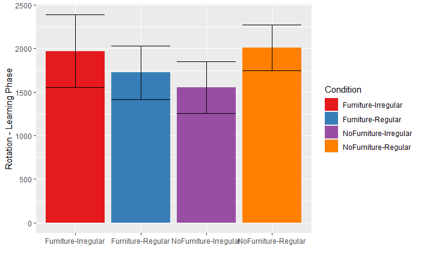

```r
d <- Rmisc::summarySE(data.locomotion.condition.learning.eliminated, measurevar = "Rotation", groupvars = c("Condition"))
ggplot(d, aes(x = Condition, y = Rotation, fill = Condition)) + geom_bar(stat = "identity") + geom_errorbar(aes(ymin=Rotation-ci, ymax=Rotation+ci)) + scale_fill_manual(values=c("#e41a1c", "#377eb8", "#984ea3", "#ff7f00")) + labs(y = "Rotation - Learning Phase", x = "")
```

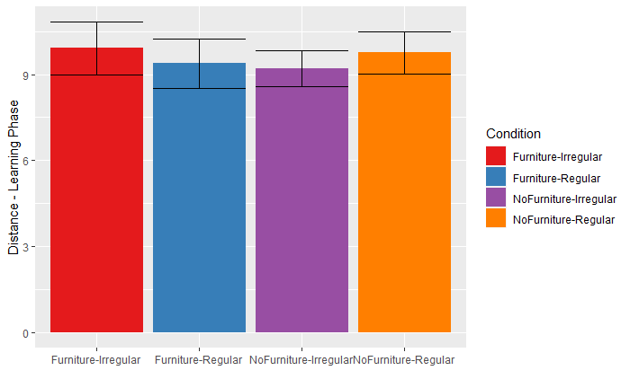

```r
d2 <- Rmisc::summarySE(data.locomotion.condition.learning.eliminated, measurevar = "Distance", groupvars = c("Condition"))
ggplot(d2, aes(x = Condition, y = Distance, fill = Condition)) + geom_bar(stat = "identity") + geom_errorbar(aes(ymin=Distance-ci, ymax=Distance+ci)) + scale_fill_manual(values=c("#e41a1c", "#377eb8", "#984ea3", "#ff7f00")) + labs(y = "Distance - Learning Phase", x = "")
```

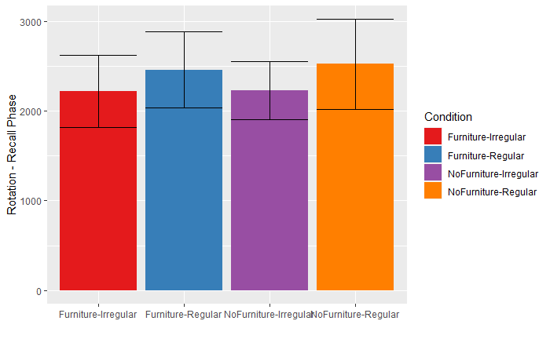

```r
d3 <- Rmisc::summarySE(data.locomotion.condition.recall.eliminated, measurevar = "Rotation", groupvars = c("Condition"))
ggplot(d3, aes(x = Condition, y = Rotation, fill = Condition)) + geom_bar(stat = "identity") + geom_errorbar(aes(ymin=Rotation-ci, ymax=Rotation+ci)) + scale_fill_manual(values=c("#e41a1c", "#377eb8", "#984ea3", "#ff7f00")) + labs(y = "Rotation - Recall Phase", x = "")
```

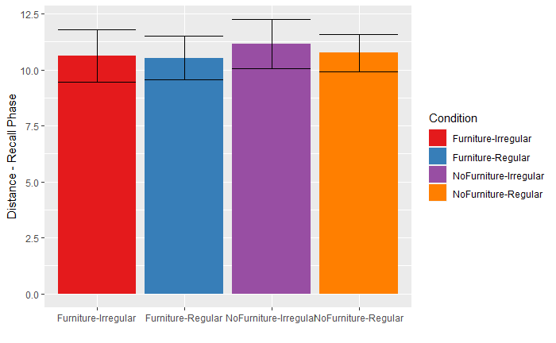

```r
d4 <- Rmisc::summarySE(data.locomotion.condition.recall.eliminated, measurevar = "Distance", groupvars = c("Condition"))
ggplot(d4, aes(x = Condition, y = Distance, fill = Condition)) + geom_bar(stat = "identity") + geom_errorbar(aes(ymin=Distance-ci, ymax=Distance+ci)) + scale_fill_manual(values=c("#e41a1c", "#377eb8", "#984ea3", "#ff7f00")) + labs(y = "Distance - Recall Phase", x = "")
```

From the ANOVA test of Aligned Ranked data and a post-hoc comparisons for the main effect, we find a significant difference between the Condition “NoFurniture-Irregular” and “NoFurniture-Regular” on the head rotation data. It tells us that when participants in a room without any furniture, they perform more head rotations on Regular layout than Irregular layout.